# Notebook Réducion de dimensionalité projets 2 à 4

```r
#install.packages("FactoMineR")
library("FactoMineR")
```

Installation et chargement de factoextra pour visualisation

```r
library("devtools")
#install_github("kassambara/factoextra")
```

```r
library("factoextra")
```

```r
#install.packages("scatterplot3d") # Install
library("scatterplot3d") # load
```

```r
library (ggplot2)
```

```r
#install.packages("gtable")
library(gtable)
```

# 3 Projet 2 : S’entraîner sur les données décathlon

## 0. Préparation des données

```r
#lecture du fichier jeu de données Data Analyst
decathlonDA <- read.csv("C:/Users/vgdb/Documents/DUDA/decathlon.csv", header=TRUE, sep = ",", dec = ".", fileEncoding = "latin1", check.names = FALSE, row.names = 1)
#decathlonDA

#suppression de la colonne supplémentaire
#decathlonDA <- subset (decathlonDA, select = -c(Id))

#conversion de variable qualitative en factor
decathlonDA$Competition <- as.factor(decathlonDA$Competition)
#decathlonDA
```

## 1. Mobilisez les données du jeu de données sur le décathlon, effectuez quelques analyses de réduction de dimensionnalité par ACP, et produisez un cercle des corrélations

```r
#Quelques statistiques
decathlonDA.active <- decathlonDA[,1:12]
summary (decathlonDA.active)
```

```
      100m         Long.jump       Shot.put       High.jump          400m
 Min.   :10.44   Min.   :6.61   Min.   :12.68   Min.   :1.850   Min.   :46.81
 1st Qu.:10.85   1st Qu.:7.03   1st Qu.:13.88   1st Qu.:1.920   1st Qu.:48.93
 Median :10.98   Median :7.30   Median :14.57   Median :1.950   Median :49.40
 Mean   :11.00   Mean   :7.26   Mean   :14.48   Mean   :1.977   Mean   :49.62
 3rd Qu.:11.14   3rd Qu.:7.48   3rd Qu.:14.97   3rd Qu.:2.040   3rd Qu.:50.30
 Max.   :11.64   Max.   :7.96   Max.   :16.36   Max.   :2.150   Max.   :53.20
  110m.hurdle        Discus        Pole.vault       Javeline         1500m
 Min.   :13.97   Min.   :37.92   Min.   :4.200   Min.   :50.31   Min.   :262.1
 1st Qu.:14.21   1st Qu.:41.90   1st Qu.:4.500   1st Qu.:55.27   1st Qu.:271.0
 Median :14.48   Median :44.41   Median :4.800   Median :58.36   Median :278.1
 Mean   :14.61   Mean   :44.33   Mean   :4.762   Mean   :58.32   Mean   :279.0
 3rd Qu.:14.98   3rd Qu.:46.07   3rd Qu.:4.920   3rd Qu.:60.89   3rd Qu.:285.1
 Max.   :15.67   Max.   :51.65   Max.   :5.400   Max.   :70.52   Max.   :317.0
      Rank           Points
 Min.   : 1.00   Min.   :7313
 1st Qu.: 6.00   1st Qu.:7802
 Median :11.00   Median :8021
 Mean   :12.12   Mean   :8005
 3rd Qu.:18.00   3rd Qu.:8122
 Max.   :28.00   Max.   :8893
```

```r
# Standardisation et représentation des variables centrées et réduites (ou standardisées)

library(dplyr)

#Centrer et réduire les variables
decathlonDACR <- decathlonDA %>% mutate_at(c('100m', 'Long.jump','Shot.put', 'High.jump', '400m', '110m.hurdle', 'Discus', 'Pole.vault', 'Javeline', '1500m'), ~(scale(.) %>% as.vector), row.names = 1)
decathlonDACR
```

|  | 100m | Long.jump | Shot.put | High.jump | 400m | 110m.hurdle | Discus | Pole.vault | Javeline | 1500m | Rank | Points | Competition |
| --- | --- | --- | --- | --- | --- | --- | --- | --- | --- | --- | --- | --- | --- |
| SEBRLE | 0.15949639 | 1.0113727 | 0.428087000 | 1.04744448 | 0.16789492 | 0.17835587 | -0.17040740 | 0.9264789 | 1.009653240 | 1.08582657 | 1 | 8217 | Decastar |
| CLAY | -0.90504930 | 0.4424756 | -0.263301610 | -1.31341860 | -0.21356911 | -1.17818270 | 1.89303852 | 0.5667665 | 0.379839017 | 1.92535303 | 2 | 8122 | Decastar |
| KARPOV | 0.08345742 | 0.1264216 | 0.355309251 | 0.71017832 | -1.08053282 | -1.09339904 | 1.36903575 | 0.5667665 | -1.658770177 | 1.81398728 | 3 | 8099 | Decastar |
| BERNARD | 0.08345742 | -0.0948162 | -0.275431235 | -0.63888629 | -0.59503314 | 0.81423333 | -1.02302207 | 2.0056163 | 0.922639433 | 0.09210136 | 4 | 8067 | Decastar |
| YURKOV | 1.30008106 | -0.5372918 | 0.864753490 | 1.38471063 | 0.69674279 | 1.49250261 | 0.57266997 | -0.1526585 | 1.061447173 | -0.22486271 | 5 | 8036 | Decastar |
| WARNERS | 0.42563282 | 1.0745835 | -0.202653486 | 0.03564602 | -0.81177407 | -0.79665623 | -0.95493132 | 0.5667665 | -1.356293610 | -0.07923057 | 6 | 8030 | Decastar |
| ZSIVOCZKY | 0.50167179 | 0.1264216 | -1.209412340 | 0.37291217 | -0.86379189 | -0.92383172 | 0.39800238 | -1.2317958 | -0.610460978 | -0.94445683 | 7 | 8004 | Decastar |
| McMULLEN | -0.63891288 | 0.1580270 | -0.869782847 | 1.72197679 | 0.25459130 | -0.47871750 | 0.02498346 | -1.2317958 | -0.403285246 | 0.52043119 | 8 | 7995 | Decastar |
| MARTINEAU | 2.44066574 | -1.4222429 | 0.112716757 | -0.30162014 | 0.45399295 | 0.68705783 | 0.96937262 | 0.5667665 | -1.240275200 | -1.44988603 | 9 | 7802 | Decastar |
| HERNU | 1.41413953 | 0.9481620 | -0.081357239 | -1.31341860 | 1.28627811 | 0.96260473 | 0.19669058 | 0.2070540 | -0.233401147 | 0.52043119 | 10 | 7733 | Decastar |

[output cut: 31 more lines]

```r
NA
NA
NA
```

```r
res.pcacr <- PCA(decathlonDACR[,1:10], graph=FALSE)
print(res.pcacr$eig)
```

```
        eigenvalue percentage of variance cumulative percentage of variance
comp 1   3.2719055              32.719055                          32.71906
comp 2   1.7371310              17.371310                          50.09037
comp 3   1.4049167              14.049167                          64.13953
comp 4   1.0568504              10.568504                          74.70804
comp 5   0.6847735               6.847735                          81.55577
comp 6   0.5992687               5.992687                          87.54846
comp 7   0.4512353               4.512353                          92.06081
comp 8   0.3968766               3.968766                          96.02958
comp 9   0.2148149               2.148149                          98.17773
comp 10  0.1822275               1.822275                         100.00000
```

```r
barplot(res.pcacr$eig[, 2], names.arg=1:nrow(res.pcacr$eig),
       main = "Variance",
       xlab = "Composantes Principales",
       ylab = "Variance %age - bleu cumul - rouge",
       col ="steelblue", ylim=c(0,103))
# Add la part de variance cumulée
lines(x = 1:nrow(res.pcacr$eig), cumsum(res.pcacr$eig[, 2]),
      type="b", pch=19, col = "red", ylim=c(0,103))
```

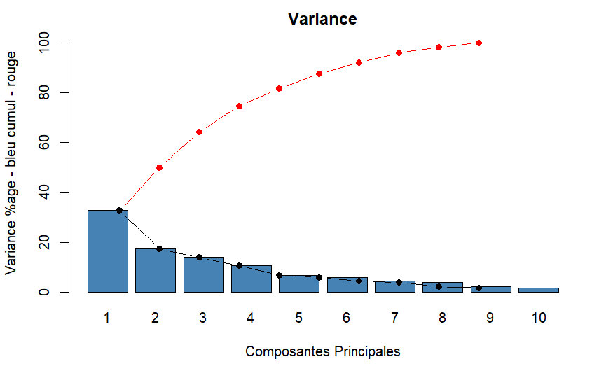

```r
lines(x = 1:nrow(res.pcacr$eig), res.pcacr$eig[, 2],
      type="b", pch=19, col = "black")
```

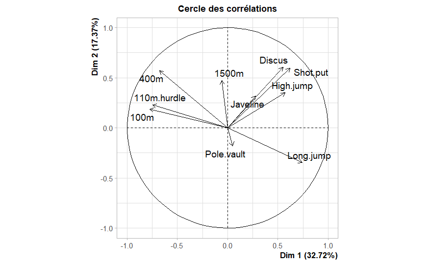

```r
plot.PCA(res.pcacr,choix='var',title="Cercle des corrélations")
```

## 2. Dans une seconde figure, repésentez les individus sur un plan factoriel. La taille des bulles représentant les individus doit être liée `a la qualité de leur représentation

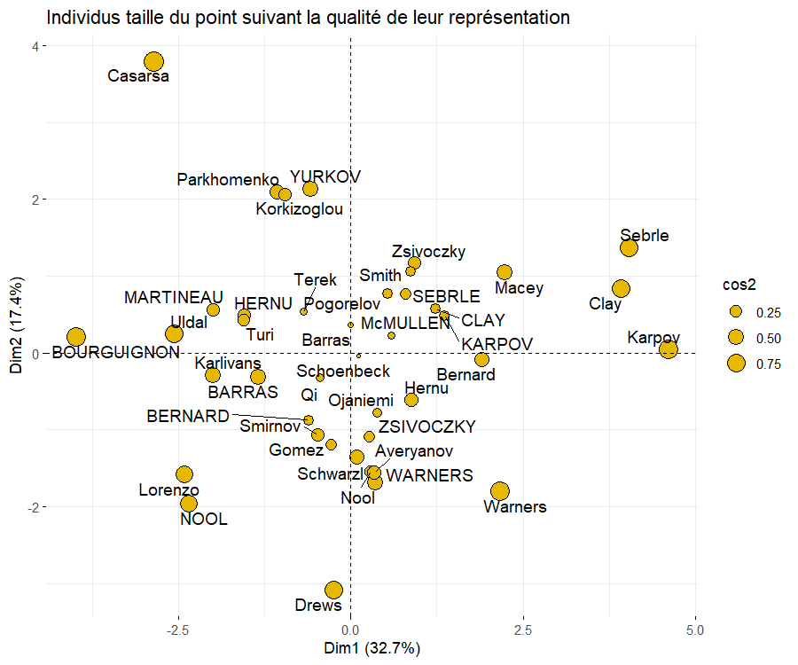

```r
# Représentation des individus
fviz_pca_ind(res.pcacr, label = "all", pointshape = 21,fill = "#E7B800", pointsize = "cos2", repel = TRUE, title="Individus taille du point suivant la qualité de leur représentation")
```

```r
#plot.PCA(res.pcacr,invisible=c('quali','ind.sup'),title="Analyse des Composantes Principales variables centrées réduites",label ='none',habillage='Competition',col.quali.sup='#FF00FF')


#"$ind"              "results for the individuals"
#"$ind$coord"        "coord. for the individuals"
#"$ind$cos2"         "cos2 for the individuals"
#"$ind$contrib"      "contributions of the individuals"
```

## 3. Représentez les individus dans une figure en 3D, chaque axe correspondant à une composante principale, selon le principe illustré ci-dessous

```r
#class(res.pcacr$ind$coord)
ind.coord.df <- as.data.frame(res.pcacr$ind$coord)
#ind.coord.df
#ind.coord.df %>% select (Dim.1, Dim.2, Dim.3)
#select (ind.coord.df, Dim.1, Dim.2, Dim.3)
```

```r
#install.packages("rgl")
library("rgl")
print ((ind.coord.df))
```

|  | Dim.1 | Dim.2 | Dim.3 | Dim.4 | Dim.5 |
| --- | --- | --- | --- | --- | --- |
| SEBRLE | 0.791627717 | 0.77161120 | 0.8268411940 | 1.17462736 | 0.70715903 |
| CLAY | 1.234990563 | 0.57457807 | 2.1412469664 | -0.35484483 | -1.97457138 |
| KARPOV | 1.358214936 | 0.48402090 | 1.9562579869 | -1.85652411 | 0.79521472 |
| BERNARD | -0.609515083 | -0.87462853 | 0.8899406619 | 2.22061245 | 0.36163619 |
| YURKOV | -0.585968338 | 2.13095422 | -1.2251567968 | 0.87357915 | 1.25136918 |
| WARNERS | 0.356889530 | -1.68495667 | 0.7665531449 | -0.58930466 | 1.00166155 |
| ZSIVOCZKY | 0.271774781 | -1.09377558 | -1.2827673831 | -1.62156457 | 0.04407327 |
| McMULLEN | 0.587516189 | 0.23072991 | -0.4176329823 | -1.52423275 | 0.25151965 |
| MARTINEAU | -1.995359298 | 0.56099598 | -0.7299466011 | -0.54219127 | 1.57821348 |
| HERNU | -1.546076462 | 0.48838301 | 0.8407858519 | 0.33119470 | -0.23498029 |

[output cut: 31 more lines]

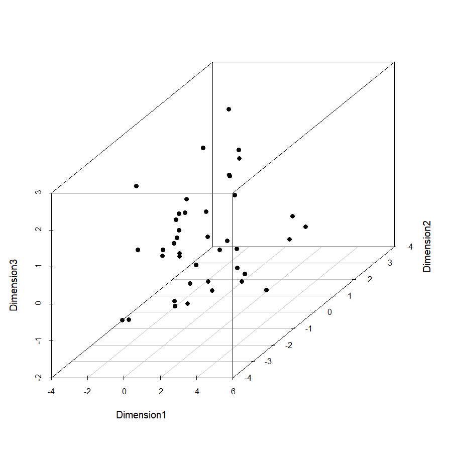

```r
scatterplot3d(ind.coord.df$Dim.1,
              ind.coord.df$Dim.2,
              ind.coord.df$Dim.3,
              xlab = "Dimension1",
              ylab = "Dimension2",
              zlab = "Dimension3",
#              labels = rownames(ind.coord.df),
              pch=16)
```

## 4. Nommez les cinq premiers axes et justifiez votre choix sur la base d’une table, créée vers la fin du Projet 1

```r
#calcul des saturations des différentes variables sur les différents axes
saturation <- sweep(res.pcacr$var$coord,2,sqrt(res.pcacr$eig[1:ncol(res.pcacr$var$coord),1]),FUN="/")
saturation
```

```
                  Dim.1      Dim.2       Dim.3       Dim.4       Dim.5
100m        -0.42829627  0.1419891 -0.15557953 -0.03678703  0.36518741
Long.jump    0.41015201 -0.2620794  0.15372674  0.09901016  0.04432336
Shot.put     0.34414444  0.4539470 -0.01972378  0.18539458  0.13431954
High.jump    0.31619436  0.2657761 -0.21894349 -0.13189684  0.67121760
400m        -0.37571570  0.4320460  0.11091758  0.02850297 -0.10597034
110m.hurdle -0.41255442  0.1735910 -0.07815576  0.28290068  0.19857266
Discus       0.30542571  0.4600244  0.03623770 -0.25259074 -0.12667770
Pole.vault   0.02783081 -0.1368411  0.58361717  0.53649480  0.39873734
Javeline     0.15319802  0.2405071 -0.32874217  0.69285498 -0.36873120
1500m       -0.03210733  0.3598049  0.65987362 -0.15669648 -0.18557094
```

```r
# on repère la discipline avec la saturation la plus importante pour chaque axe
for (i in 1:ncol(saturation)) {
  max <- names(which.max(saturation[,i]))
  cat ("Axe ")
  cat (i)
  cat (" : ")
  print (max)
}
```

```
Axe 1 : [1] "Long.jump"
Axe 2 : [1] "Discus"
Axe 3 : [1] "1500m"
Axe 4 : [1] "Javeline"
Axe 5 : [1] "High.jump"
```

La saturation exprime la relation entre la variable et l’axe. Chaque axe a été renommé par le nom de la variable pour laquelle la saturation est maximale.

## 5. Précisez les avantages et inconvénients respectifs des méthodes kmeans et CAH

La classification kmeans nécessite de fixer le nombre de cluster tandis que le découpage en clusters sur une classification hierarchique peut se faire à différents niveaux de l’arbre une fois que le regroupement des individus en arbre est réalisée. La classification hierarchique nécessite plus de stockage car l’arbre complet est stocké. Cela peut être compliqué dans le cas où le volume du jeu de données est trop importante. La classification kmeans est très puissante et adaptée à un volume important de données. La classification hierarchique est reproductible tandis que la classification kmeans débutant par une attribution aléatoire d’étiquettes aux différents individus peut donner des résultats différents à chaque réalisation.

## 6. Réalisez un clustering par kmeans, puis un par CAH, et représentez les clusters ainsi créés sur le plan factoriel. Une figure par méthode

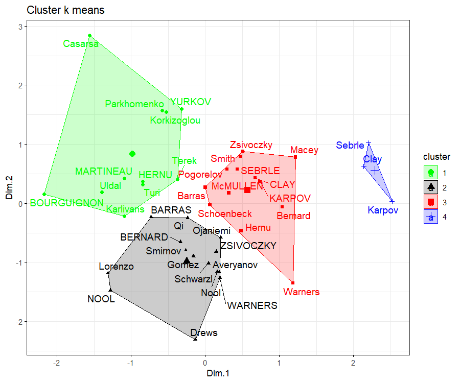

```r
#cluster par kmeans
#res.pcacr$ind$coord[,1:2]
res.kmcrpc12 <- kmeans(res.pcacr$ind$coord[,1:2], centers = 4, nstart = 20)
#res.kmpc12 <- kmeans(res.pca$ind$coord[,1:2], centers = 3, nstart = 20)

fviz_cluster(res.kmcrpc12, data = res.pcacr$ind$coord[,1:2],
             palette = c("green", "black", "red", "blue"),
             geom = c("point","text"), repel = TRUE,
             ellipse.type = "convex",
             ggtheme = theme_bw(),
             title = "Cluster k means"
             )
```

```r
source(url("https://raw.githubusercontent.com/larmarange/JLutils/master/R/clustering.R"))
```

Cluster par Classification Ascendant Hiérarchique

```r
res.hcpc<-HCPC(res.pcacr,consol=FALSE,nb.clust=4,graph=FALSE)
#print (res.hcpc$desc.var)
```

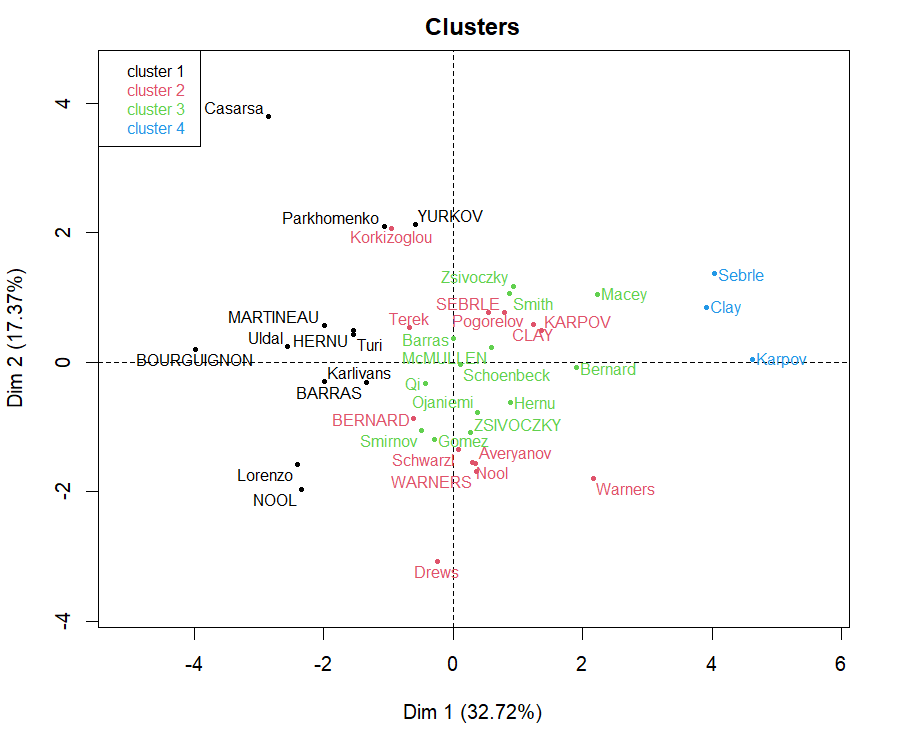

```r
plot(res.hcpc, axes=c(1,2), choice="map",
     ind.names=TRUE, rect=FALSE, draw.tree=FALSE, title = "Clusters")
```

Dans cette classification, on voit que YURKOV, Parkhomenko et Korkizoglou sont très proches. Malgré cette proximité Korkizoglou est dans le cluster 2 avec des individus très éloignés comme Drews. Le résultat n’est pas satisfaisant. Cherchons une autre méthode.

```r
#cluster par CAH method = complete
#res.pcacr$ind$coord[,1:2]
dist_mat <- dist(res.pcacr$ind$coord[,1:2], method = "euclidean")
hclust.out <- hclust(d = dist_mat, method="complete")
#cut.cah <- cutree(hclust.out, k=6)
#cut.cah
#summary (hcust.out)
```

```r
# on utilise la fontion best cut pour trouver le meilleur nombre de cluster (méthode complète)
best.cutree(hclust.out)
```

```
[1] 4
```

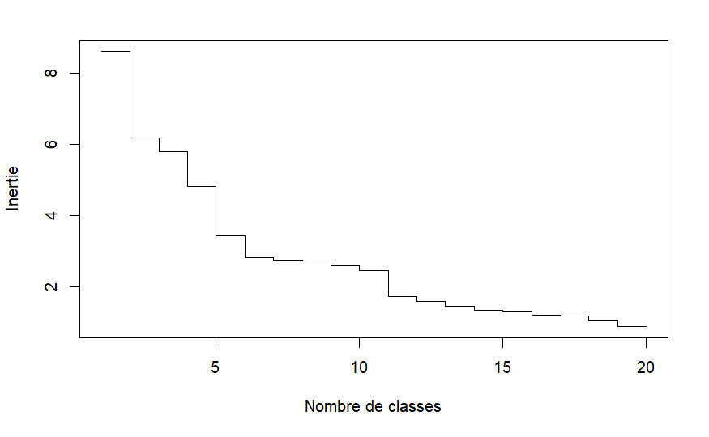

```r
# Saut d'inerties du dendrogramme
inertie <- sort(hclust.out$height, decreasing = TRUE)
plot(inertie[1:20], type = "s", xlab = "Nombre de classes", ylab = "Inertie")
```

```r
#cluster par CAH method = ward.D2
datacah = res.pcacr$ind$coord[,1:2]
dist_mat <- dist(datacah)
hclust.out <- hclust(d = dist_mat, method="ward.D2")
#cut.cah
#summary (hcust.out)
```

```r
# on utilise la fontion best cut pour trouver le meilleur nombre de cluster (méthode ward.D2)
best.cutree(hclust.out)
```

```
[1] 5
```

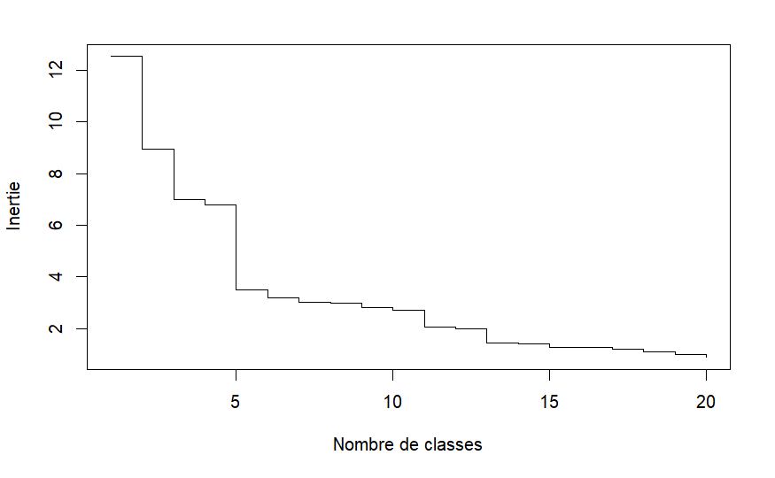

```r
# Saut d'inerties du dendrogramme
inertie <- sort(hclust.out$height, decreasing = TRUE)
plot(inertie[1:20], type = "s", xlab = "Nombre de classes", ylab = "Inertie")
```

```r
cut.cah <- cutree(hclust.out, k=5)
```

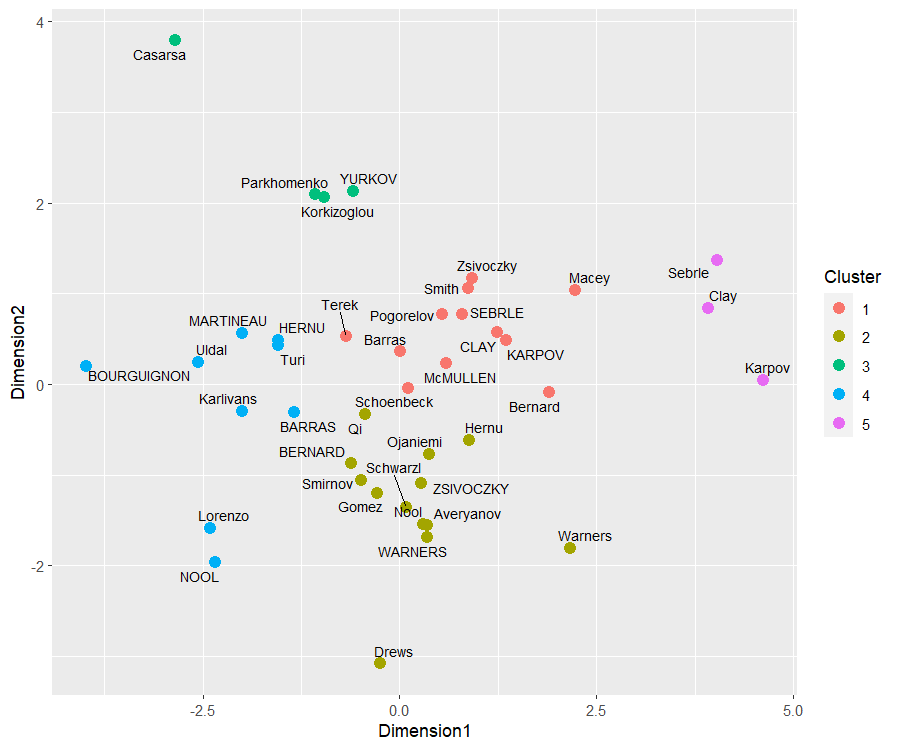

```r
library(ggrepel)
plotdata <- data.frame(cbind(datacah, cut.cah))
#plotdata
plotdata$cut.cah <- as.factor(plotdata$cut.cah)
#print(plotdata)
#ggplot(plotdata, aes(x=Dim.1, y=Dim.2, color=cut.cah)) + geom_point(size=2) + geom_text (label=rownames(plotdata),nudge_x = 0.25, nudge_y =0.25,check_overlap=T)
ggplot(plotdata, main = "Cluster CAH méthode ward2") + geom_point (aes(Dim.1, Dim.2, color=cut.cah), size=3) + geom_text_repel (aes(Dim.1, Dim.2,label=rownames(plotdata)), size = 3) + labs(x="Dimension1", y="Dimension2", color = "Cluster") + theme(legend.position = "right")
```

Cette méthode de cluster permet un meilleur regroupement des individus.

## 7. Dans le cas de la CAH, représentez un dendogramme à plat, comme ci-dessous. Comment avez-vous choisi en définitive le nombre de clusters que vous retenez ?

Les méthodes employées donnent des résultats différents concernant le nombre optimal de cluster et leur composition. Plusieurs itérations ont été nécessaires pour parvenir à un résultat jugé optimal. Le but était notamment de regrouper trois individus proches (YURKOV, Parkhomenko et Korkizoglou) alors que plusieurs méthodes (hcpc avec 4 et avec 5 clusters, hclust method complete avec 4 et avec 5 clusters) regroupent Korkizoglou avec Drews par exemple qui est plus éloigné. Le hclust methode ward.D2 avec 5 clusters me paraît être la meilleure répartition en clusters. Les masses sont regroupées et les extrèmes sont rattachées aux individus qui sont les plus proches.

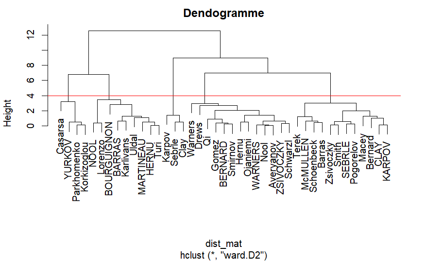

```r
# dendogramme de la méthode retenue
plot(hclust.out, main = "Dendogramme")
abline(h = 4, col = "red")
```

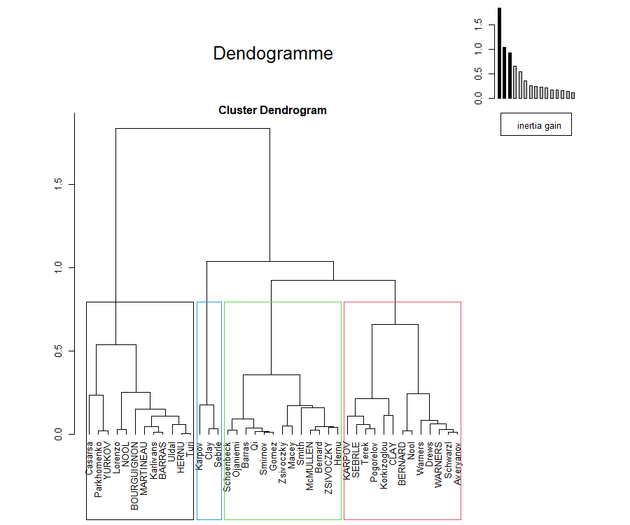

```r
# autre dendogramme avec la méthode hcpc (non retenue)
plot(res.hcpc, axes=c(1,2), choice="tree",
     ind.names=TRUE, rect=TRUE, draw.tree=TRUE, title = "Dendogramme")
```

## 8. Représentez un dendogramme en trois dimensions, avec le plan factoriel, comme ci-dessous

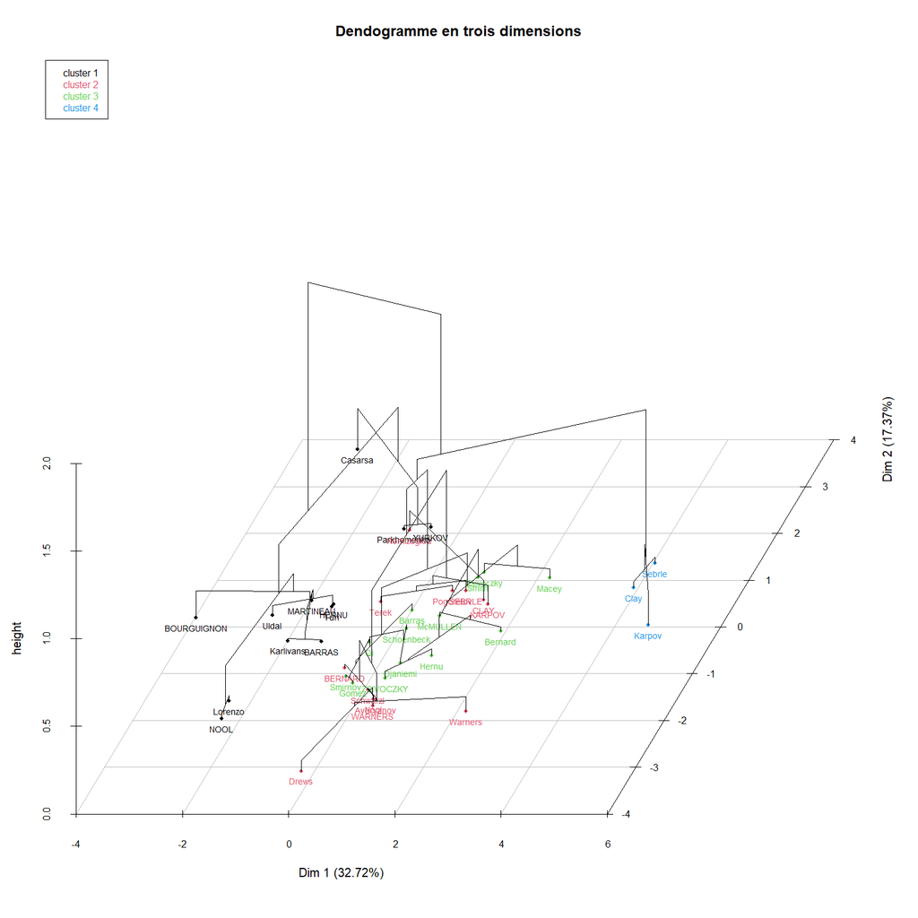

```r
# dendogramme en 3D avec la méthode hcpc (non retenue)
plot(res.hcpc, choice="3D.map", angle=60, title = "Dendogramme en trois dimensions")
```

# 4 Projet 3 : Dating et analyse des correspondances multiples

## 1. Expliquez dans quelles circonstances mobilise-t-on une analyse des correspondances ou une analyse des correspondances multiples

L’analyse des correspondances multiples s’applique aux jeux de données comportant plusieurs variables qualitatives alors que l’analyse en composantes principales s’applique aux variables quantitatives.

## 2. Représenter les différentes variables qualitatives de ce jeu de données dans un plan factoriel, comme dans la figure ci-dessous. Il y a trop d’individus pour les représenter.

Le jeu de données comprend des variables qualitatives comme les dates (création, connexion, de mise à jour de la photo) et des variables booléennes comme voyage, laugh, photot.keke, photo.beach ainsi qu’une variable genre. On applique donc une analyse des correspondances multiples.

Plusieurs essais sont réalisés

1. ACM sur toutes les variables qualitatives (y compris les dates dans leur format complet) : les dates complètes donnent lieu à trop de modalités. La variance expliquée est de 0,059 sur la dimension 1 et de 0,056 sur la dimension 2.
2. Regroupement des dates en ne gardant que la notion d’année et utilisation de toutes les variables qualitatives. Le nuage des individus est en forme de parabole, révèlant un effet Guttman. Sur l’axe horizontal, sont opposés les individus aux années faibles (2009 à 2013) à gauche aux individus aux annnées élevés (2015-2019) à droite. Sur l’axe vertical, sont opposés les individus ayant des années extrêmes (2009-2010 en extrême bas et 2017 à 2019 en extrême haut). L’effet des dates effacent l’effet des autres variables qualitatives. La variances expliquée est faible 7,9% sur la dimension 1 et 7,85% sur la dimension 2.
3. Création d’une catégorie pour les dates prenant uniquement 3 valeurs suivant l’échelle : ancien (années 2009 à 2011), moyen (années 2012 à 2016) et récent (années 2017 à 2020). Le nuage des individus est plus en forme de V. L’effet Guttman perdure. La limite des modalités pour les dates ne permet pas de visualiser l’effet des autres variables qualitatives. La variance expliquée est de 24,8% sur la dimension 1 et 24,4% sur la dimension 2.
4. ACM avec les années en variables qualitatives supplémentaires. Cette option est retenue pour la suite de l’analyse.

### Préparation des données

```r
#lecture du fichier jeu de données Data Analyst
datingDA <- read.csv("C:/Users/vgdb/Documents/DUDA/users.db.csv", header=TRUE, sep = ",", dec = ".", fileEncoding = "latin1", check.names = FALSE, row.names = 1)
#datingDA

#tableau du nombre de modalités par variables à ajouter et regroupement des variables de dates en mois année. Distribution des variables ?

#suppression de colonnes inutiles
sum(is.na(datingDA$last.pr.update)) #3000 valeur null pour un DF de 3000 lignes. La colonne peut être supprimée
```

```
[1] 3000
```

```r
datingDA <- subset (datingDA, select = -c(last.pr.update))
sum(is.na(datingDA)) # après cette suppression, toutes les variables du DF sont renseignées
```

```
[1] 0
```

```r
# ajout de variables d'année car les dates sont trop nombreuses et prennent trop de valeurs
datingDA$annee.crea <-format(as.Date(datingDA$date.crea,'%Y-%m-%d'),'%Y')
datingDA$annee.last.connex <-format(as.Date(datingDA$last.connex,'%Y-%m-%d'),'%Y')
datingDA$annee.last.up.photo <-format(as.Date(datingDA$last.up.photo,'%Y-%m-%d'),'%Y')

# ajout de variables d'année-mois car les dates sont trop nombreuses et prennent trop de valeurs
datingDA$anneemois.crea <-format(as.Date(datingDA$date.crea,'%Y-%m-%d'),'%Y-%m')
datingDA$anneemois.last.connex <-format(as.Date(datingDA$last.connex,'%Y-%m-%d'),'%Y-%m')
datingDA$anneemois.last.up.photo <-format(as.Date(datingDA$last.up.photo,'%Y-%m-%d'),'%Y-%m')

# création de variables années prenant 3 valeurs : ancien, moyen et récent
datingDA$annee.crea.echelle <- ifelse(datingDA$annee.crea %in% c("2009","2010","2011"),"ancien", ifelse(datingDA$annee.crea %in% c("2017","2018","2019"),"récent", "moyen"))
datingDA$annee.last.connex.echelle <- ifelse(datingDA$annee.last.connex %in% c("2009","2010","2011"),"ancien", ifelse(datingDA$annee.last.connex %in% c("2017","2018","2019", "2020"),"récent", "moyen"))
datingDA$annee.last.up.photo.echelle <- ifelse(datingDA$annee.last.up.photo %in% c("2009","2010","2011"),"ancien", ifelse(datingDA$annee.last.up.photo %in% c("2017","2018","2019", "2020"),"récent", "moyen"))



#conversion de variables qualitatives en factor

# 1- variables dates
datingDA$date.crea <- as.factor(datingDA$date.crea)
datingDA$last.connex <- as.factor(datingDA$last.connex)
datingDA$last.up.photo <- as.factor(datingDA$last.up.photo)
datingDA$annee.crea <- as.factor(datingDA$annee.crea)
datingDA$annee.last.connex <- as.factor(datingDA$annee.last.connex)
datingDA$annee.last.up.photo <- as.factor(datingDA$annee.last.up.photo)
datingDA$anneemois.crea <- as.factor(datingDA$anneemois.crea)
datingDA$anneemois.last.connex <- as.factor(datingDA$anneemois.last.connex)
datingDA$anneemois.last.up.photo <- as.factor(datingDA$anneemois.last.up.photo)
datingDA$annee.crea.echelle <- as.factor(datingDA$annee.crea.echelle)
datingDA$annee.last.connex.echelle <- as.factor(datingDA$annee.last.connex.echelle)
datingDA$annee.last.up.photo.echelle <- as.factor(datingDA$annee.last.up.photo.echelle)

# autres variables qualitatives
datingDA$gender <- as.factor(datingDA$gender)
datingDA$voyage <- as.factor(datingDA$voyage)
datingDA$laugh <- as.factor(datingDA$laugh)
datingDA$photo.keke <- as.factor(datingDA$photo.keke)
datingDA$photo.beach <- as.factor(datingDA$photo.beach)

#Ordonner les colonnes et DF avec toutes des variables
datingDAOrdre <- datingDA[,c(1,6,7,2,3,4,5,9,10,8,11,12,13,14,15,16,17,18,19,20,21,22,23)]

#datingDAOrdre
```

### Création des dataframe pour les différents essais

```r
# DF retenu, les années sont utilisées
datingDA = subset(datingDAOrdre, select = -c(1,2,3,18,19,20,21,22,23) )

# DF avec les dates au format année mois
#datingDAMoisAnnee = subset(datingDAOrdre, select = -c(1,2,3,15,16,17,21,22,23) )

#DF avec les dates au format complet
datingDateComplete = subset(datingDAOrdre, select = -c(15:23) )

#DF avec une échelle de date (ancien, moyen, récent) en fonction des années
datingDateEchelle = subset(datingDAOrdre, select = -c(1,2,3,15,16,17,18,19,20))

#datingDAOrdre
#datingDA
#datingDAMoisAnnee
#datingDateComplete
#datingDateEchelle
```

### Quelques statistiques et analyses des données

```r
#Quelques statistiques
datingDA.active <- datingDA[,1:5]
summary (datingDA.active)
```

```
     score         n.matches     n.updates.photo     n.photos         sent.ana
 Min.   :0.295   Min.   : 3.00   Min.   :-1.000   Min.   : 1.000   Min.   :-3.203
 1st Qu.:1.137   1st Qu.: 9.00   1st Qu.: 1.000   1st Qu.: 2.000   1st Qu.: 3.465
 Median :1.715   Median :15.00   Median : 2.000   Median : 3.000   Median : 4.965
 Mean   :1.953   Mean   :16.78   Mean   : 2.067   Mean   : 3.516   Mean   : 4.997
 3rd Qu.:2.518   3rd Qu.:23.00   3rd Qu.: 3.000   3rd Qu.: 5.000   3rd Qu.: 6.473
 Max.   :8.947   Max.   :61.00   Max.   : 9.000   Max.   :12.000   Max.   :13.355
```

```r
sapply(datingDA, nlevels)
```

```
              score           n.matches     n.updates.photo            n.photos
                  0                   0                   0                   0
           sent.ana         length.prof              gender              voyage
                  0                   0                   3                   2
              laugh          photo.keke         photo.beach          annee.crea
                  2                   2                   2                  11
  annee.last.connex annee.last.up.photo
                 12                  12
```

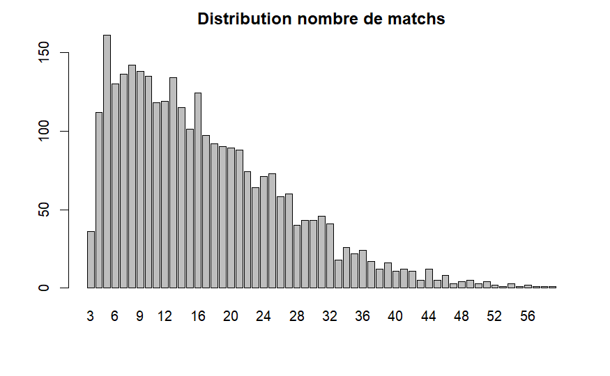

```r
barplot(table(datingDA$n.matches), main ="Distribution nombre de matchs")
```

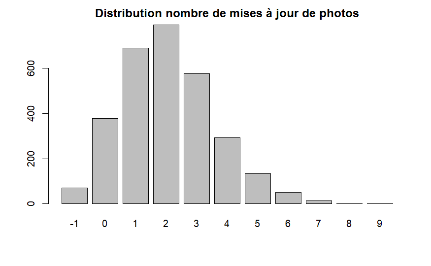

```r
barplot(table(datingDA$n.updates.photo), main ="Distribution nombre de mises à jour de photos")
```

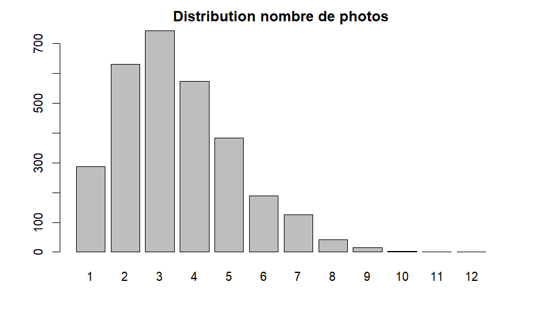

```r
barplot(table(datingDA$n.photos), main ="Distribution nombre de photos")
```

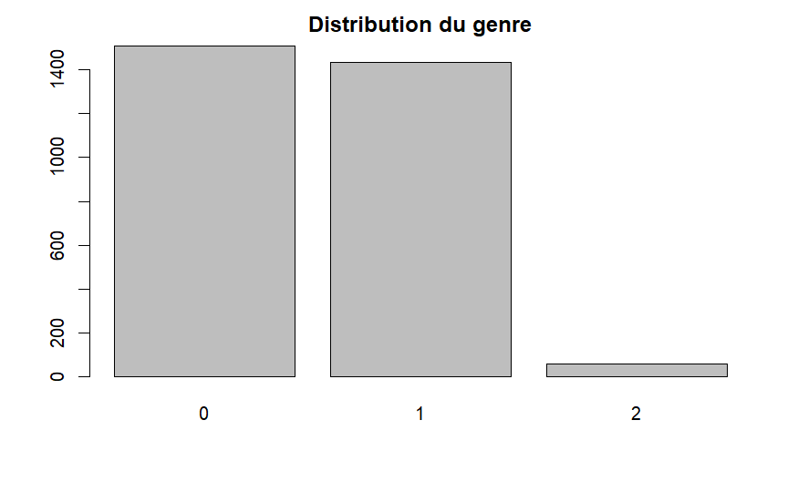

```r
barplot(table(datingDA$gender), main ="Distribution du genre")
```

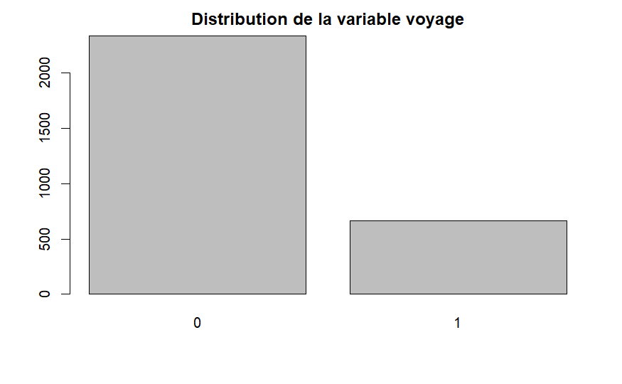

```r
barplot(table(datingDA$voyage), main ="Distribution de la variable voyage")
```

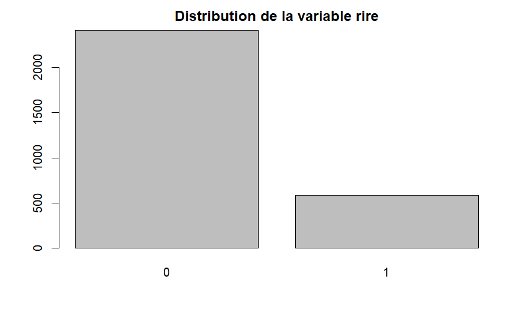

```r
barplot(table(datingDA$laugh), main ="Distribution de la variable rire")
```

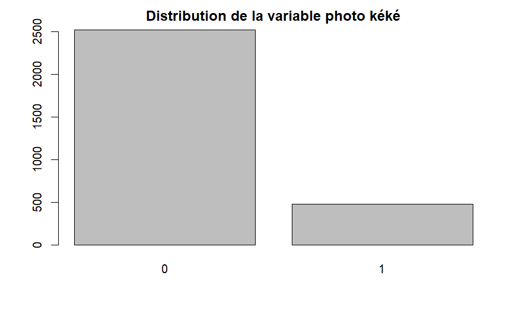

```r
barplot(table(datingDA$photo.keke), main ="Distribution de la variable photo kéké")
```

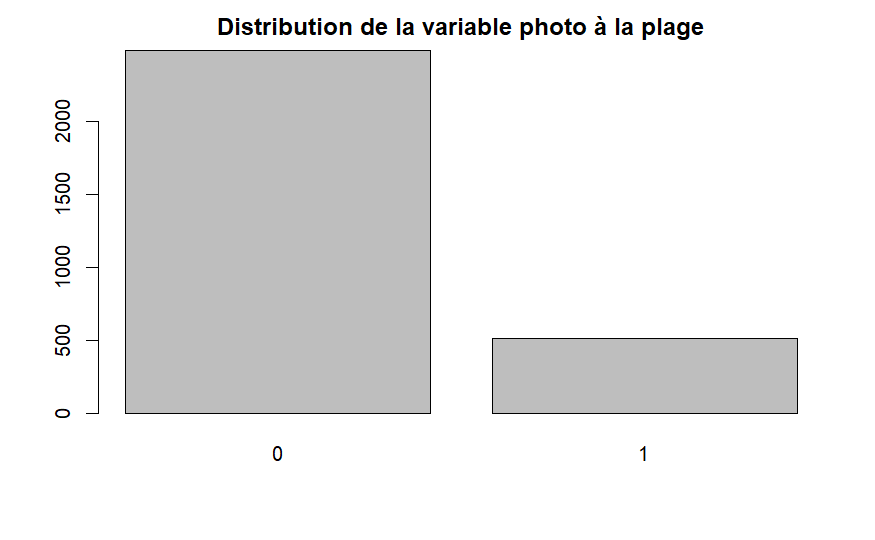

```r
barplot(table(datingDA$photo.beach), main ="Distribution de la variable photo à la plage")
```

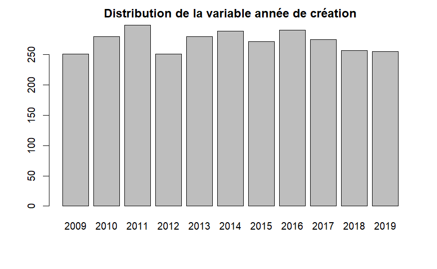

```r
barplot(table(datingDA$annee.crea), main ="Distribution de la variable année de création")
```

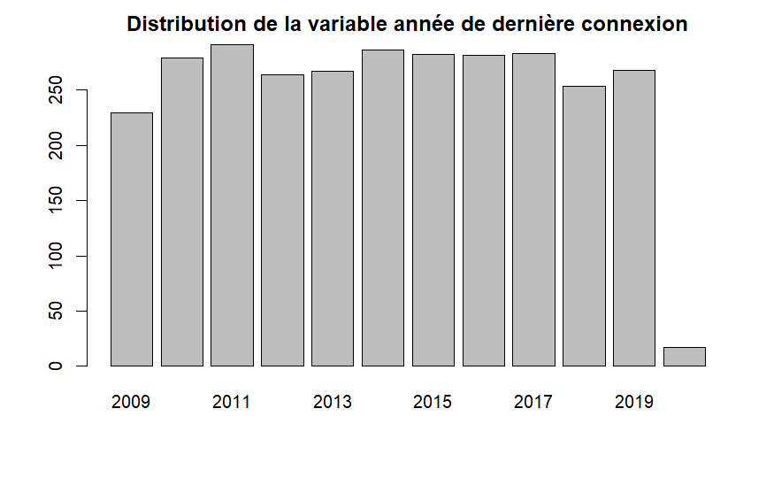

```r
barplot(table(datingDA$annee.last.connex), main ="Distribution de la variable année de dernière connexion")
```

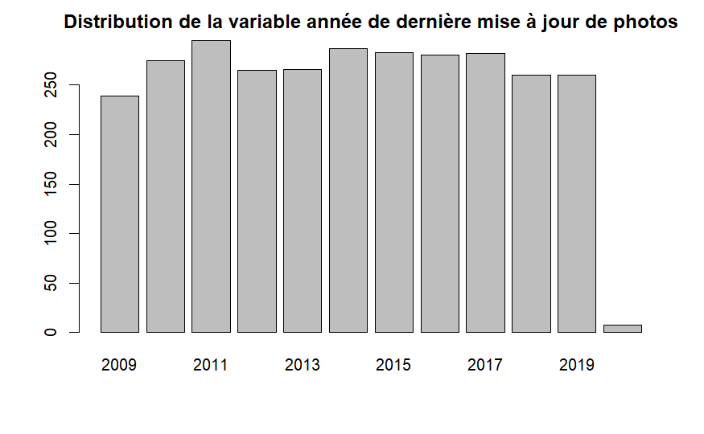

```r
barplot(table(datingDA$annee.last.up.photo), main ="Distribution de la variable année de dernière mise à jour de photos")
```

```r
library(FactoMineR)
```

### Essai numéro 1) ACM sur toutes les variables qualitatives (y compris les dates dans leur format complet)

```r
res.MCA.complete <- MCA(datingDateComplete, quanti.sup=c(4,5,6,7,8,9), graph=FALSE)
#summary (res.MCA) #Les dates completes prennent de nombreuses modalités qui rendent l'analyse trop complexe
```

```r
?plot.MCA
```

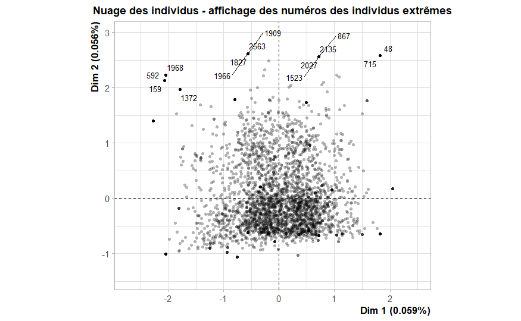

```r
res.MCA <- res.MCA.complete

# Nuage des individus
plot.MCA (res.MCA, invisible= c("var","quali.sup"), cex = 0.7, select = "coord 20", title = "Nuage des individus - affichage des numéros des individus extrêmes")
```

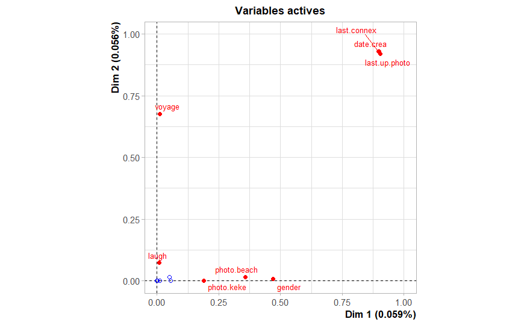

```r
# Graphe des variables

plot.MCA (res.MCA, choix = "var", cex=0.7, title = "Variables actives")
```

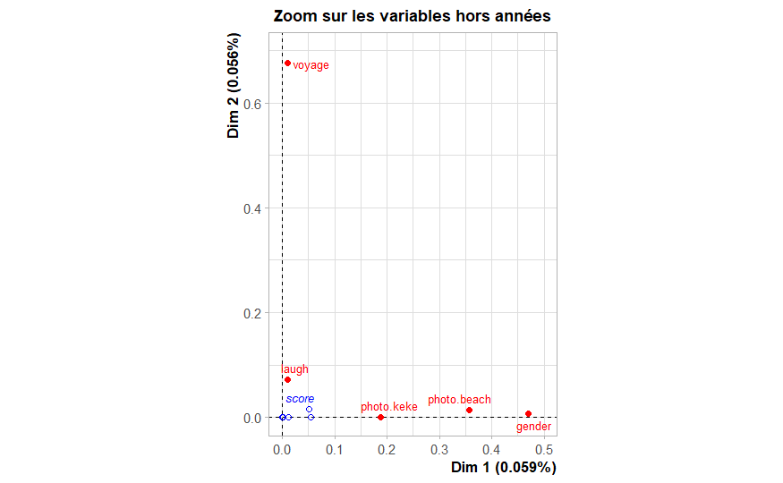

```r
plot.MCA (res.MCA, choix = "var", ylim=c(0,0.7), xlim=c(0,0.5), cex=0.7, title = "Zoom sur les variables hors années")
```

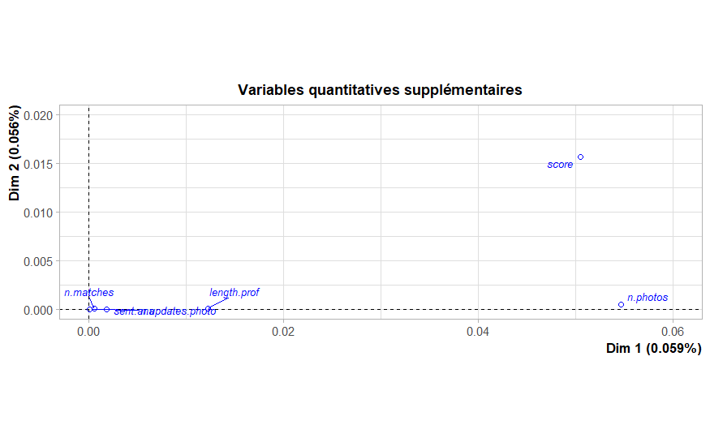

```r
plot.MCA (res.MCA, choix = "var", xlim=c(0,0.06), ylim=c(0,0.02), cex=0.7, invisible=c("var"), title="Variables quantitatives supplémentaires")
```

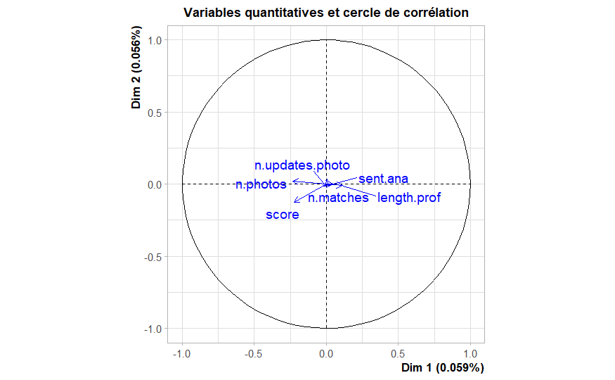

```r
# Variables quantitatives sur cercle de corrélation
plot.MCA (res.MCA, choix = "quanti.sup", title = "Variables quantitatives et cercle de corrélation")
```

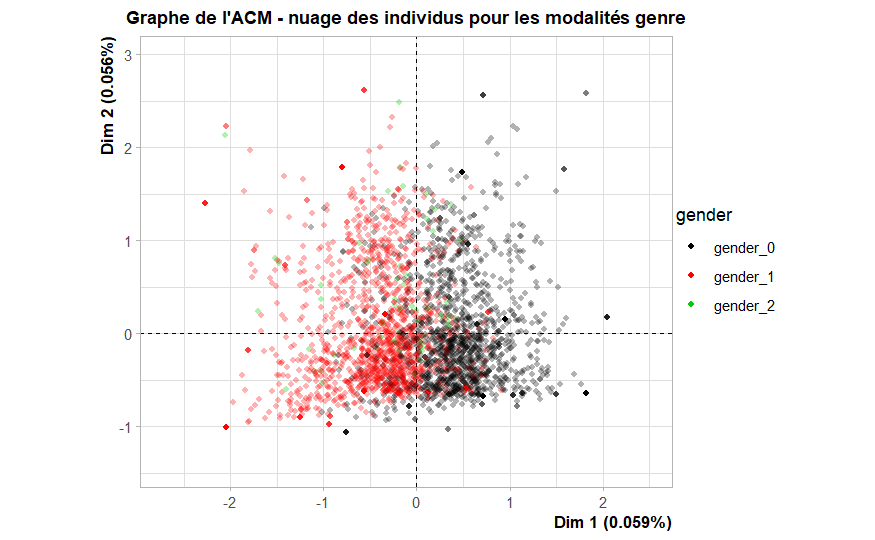

```r
# Nuage des individus pour les variables qualitatives différentiantes
plot.MCA(res.MCA,invisible= c("var","quali.sup","quanti.sup"),select="gender",habillage = "gender", title="Graphe de l'ACM - nuage des individus pour les modalités genre",label = c("none"))
```

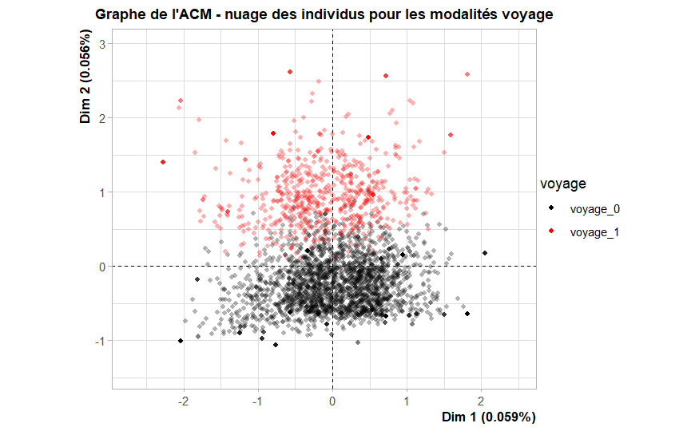

```r
plot.MCA(res.MCA,invisible= c("var","quali.sup","quanti.sup"),select="voyage",habillage = "voyage", title="Graphe de l'ACM - nuage des individus pour les modalités voyage",label = c("none"))
```

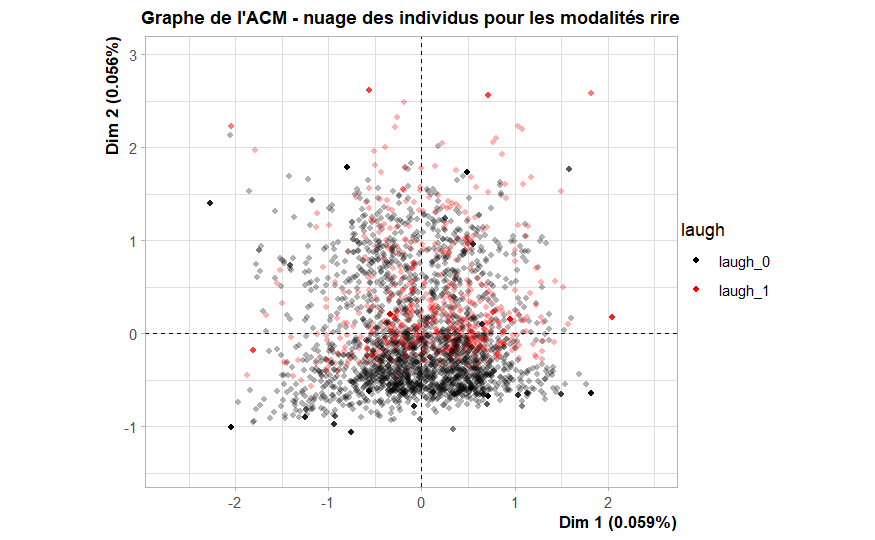

```r
plot.MCA(res.MCA,invisible= c("var","quali.sup","quanti.sup"),select="laugh",habillage = "laugh", title="Graphe de l'ACM - nuage des individus pour les modalités rire",label = c("none"))
```

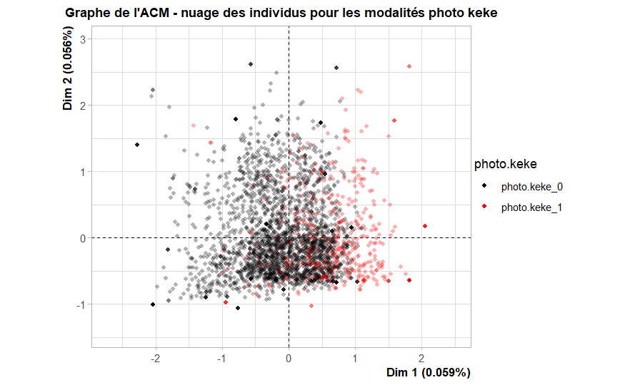

```r
plot.MCA(res.MCA,invisible= c("var","quali.sup","quanti.sup"),select="photo.keke",habillage = "photo.keke", title="Graphe de l'ACM - nuage des individus pour les modalités photo keke",label = c("none"))
```

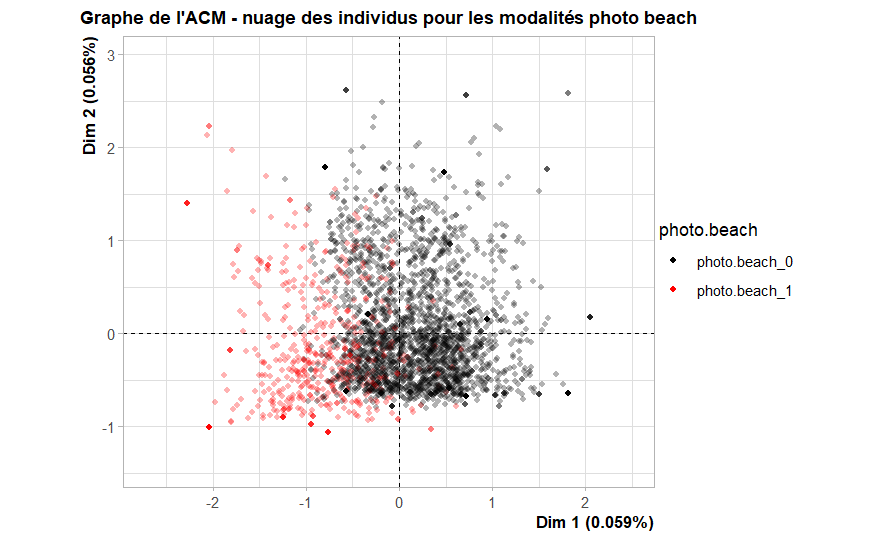

```r
plot.MCA(res.MCA,invisible= c("var","quali.sup","quanti.sup"),select="photo.beach",habillage = "photo.beach", title="Graphe de l'ACM - nuage des individus pour les modalités photo beach",label = c("none"))
```

Les variables supplémentaires sont associées à de faibles coefficient de corrélation (0.055 pour le coefficient le plus élevé pour la variable n.photos). Les informations de ces variables supplémentaires ne présentent pas d’intérêt.

La plupart des individus sont juste en dessous de l’axe horizontal. Les modalités des variables se divisent en deux soit verticalement c’est le cas pour le genre (gender_0 à droite et gender_1 à gauche) soit horizontalement (voyage_1 est en haut et voyage_0 en bas). Pour les autres variables la division est moins nette. Il n’y a toutefois quasiment pas de laugh_1 dans la partie la plus basse du nuage. De même, il n’y a quasiment pas de photo.keke_1 dans la partie gauche du nuage et de photo.becah_1 dans la partie droite du nuage.

### Essai numéro 2) Regroupement des dates en ne gardant que la notion d’année et utilisation de toutes les variables qualitatives.

La représentation en parabole permet de regrouper les années sur une échelle de 3 valeurs

```r
res.MCA<-MCA(datingDA,quanti.sup=c(1,2,3,4,5,6),graph=FALSE)
summary (res.MCA)
```

```
Call:
MCA(X = datingDA, quanti.sup = c(1, 2, 3, 4, 5, 6), graph = FALSE)


Eigenvalues
                       Dim.1   Dim.2   Dim.3   Dim.4   Dim.5   Dim.6   Dim.7   Dim.8
Variance               0.375   0.373   0.370   0.367   0.361   0.357   0.353   0.348
% of var.              7.898   7.850   7.784   7.735   7.605   7.520   7.422   7.317
Cumulative % of var.   7.898  15.747  23.531  31.266  38.872  46.391  53.813  61.130
                       Dim.9  Dim.10  Dim.11  Dim.12  Dim.13  Dim.14  Dim.15  Dim.16
Variance               0.345   0.342   0.210   0.159   0.127   0.123   0.122   0.116
% of var.              7.259   7.190   4.419   3.355   2.667   2.594   2.572   2.452
Cumulative % of var.  68.389  75.579  79.999  83.354  86.021  88.616  91.188  93.639
                      Dim.17  Dim.18  Dim.19  Dim.20  Dim.21  Dim.22  Dim.23  Dim.24
Variance               0.098   0.041   0.026   0.023   0.021   0.017   0.014   0.011
% of var.              2.053   0.863   0.548   0.491   0.440   0.354   0.288   0.229
Cumulative % of var.  95.693  96.556  97.104  97.595  98.035  98.389  98.678  98.906
                      Dim.25  Dim.26  Dim.27  Dim.28  Dim.29  Dim.30  Dim.31  Dim.32
Variance               0.008   0.007   0.007   0.006   0.005   0.005   0.004   0.003
% of var.              0.176   0.155   0.139   0.124   0.111   0.098   0.089   0.069
Cumulative % of var.  99.082  99.237  99.376  99.499  99.610  99.708  99.797  99.866
                      Dim.33  Dim.34  Dim.35  Dim.36  Dim.37  Dim.38
Variance               0.002   0.002   0.001   0.001   0.000   0.000
% of var.              0.045   0.035   0.028   0.013   0.009   0.003
Cumulative % of var.  99.911  99.946  99.974  99.988  99.997 100.000

Individuals (the 10 first)
                   Dim.1    ctr   cos2    Dim.2    ctr   cos2    Dim.3    ctr   cos2
1               | -0.631  0.035  0.108 |  0.165  0.002  0.007 |  0.694  0.043  0.130 |
2               |  0.641  0.037  0.092 |  0.075  0.001  0.001 | -0.388  0.014  0.034 |
3               |  0.929  0.077  0.181 |  0.782  0.055  0.128 |  0.697  0.044  0.102 |
4               |  0.320  0.009  0.023 | -0.600  0.032  0.080 | -0.599  0.032  0.080 |
5               |  0.100  0.001  0.002 | -0.787  0.055  0.144 | -0.420  0.016  0.041 |
6               |  0.622  0.034  0.099 |  0.080  0.001  0.002 | -0.410  0.015  0.043 |
7               | -0.758  0.051  0.118 |  0.592  0.031  0.072 | -0.241  0.005  0.012 |
8               |  0.819  0.060  0.144 |  0.516  0.024  0.057 |  0.262  0.006  0.015 |
9               |  0.826  0.061  0.160 |  0.540  0.026  0.068 |  0.279  0.007  0.018 |
10              |  0.186  0.003  0.008 | -0.755  0.051  0.132 | -0.578  0.030  0.077 |

Categories (the 10 first)
```

[output cut: 27 more lines]

```
laugh               | 0.003 0.000 0.000 |
photo.keke          | 0.002 0.001 0.000 |
photo.beach         | 0.001 0.000 0.002 |
annee.crea          | 0.997 0.991 0.979 |
annee.last.connex   | 0.997 0.992 0.984 |
annee.last.up.photo | 0.998 0.996 0.992 |

Supplementary continuous variables
                   Dim.1    Dim.2    Dim.3
score           | -0.012 |  0.025 | -0.008 |
n.matches       | -0.017 |  0.018 | -0.006 |
n.updates.photo |  0.010 |  0.012 | -0.026 |
n.photos        | -0.003 | -0.012 |  0.007 |
sent.ana        | -0.001 |  0.012 | -0.003 |
length.prof     |  0.007 | -0.044 |  0.005 |
```

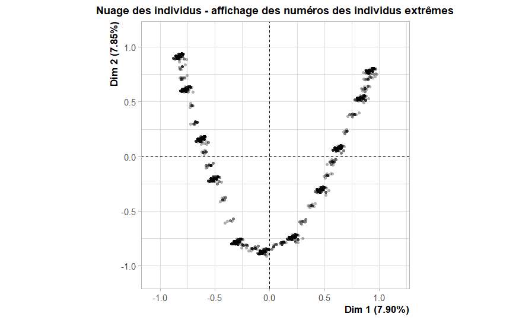

```r
# Nuage des individus
plot.MCA (res.MCA, invisible= c("var","quali.sup"), cex = 0.7, select = "coord 10", title = "Nuage des individus - affichage des numéros des individus extrêmes")
```

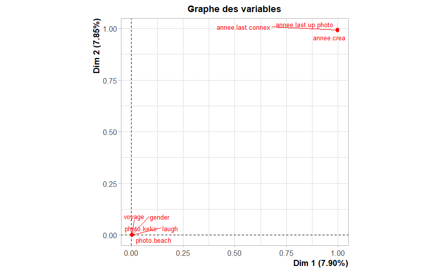

```r
# Graphe des variables
plot.MCA(res.MCA, choix='var',invisible=c('quali.sup','quanti.sup'),title="Graphe des variables", cex =0.7)
```

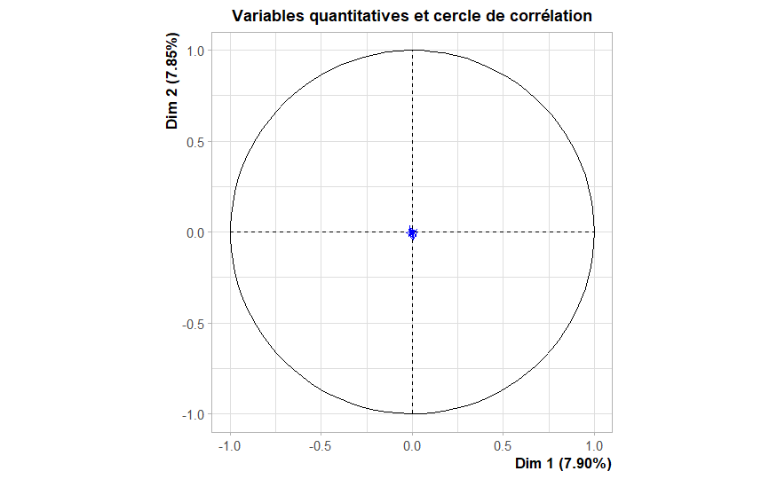

```r
# Variables quantitatives sur cercle de corrélation
plot.MCA (res.MCA, choix = "quanti.sup", title = "Variables quantitatives et cercle de corrélation")
```

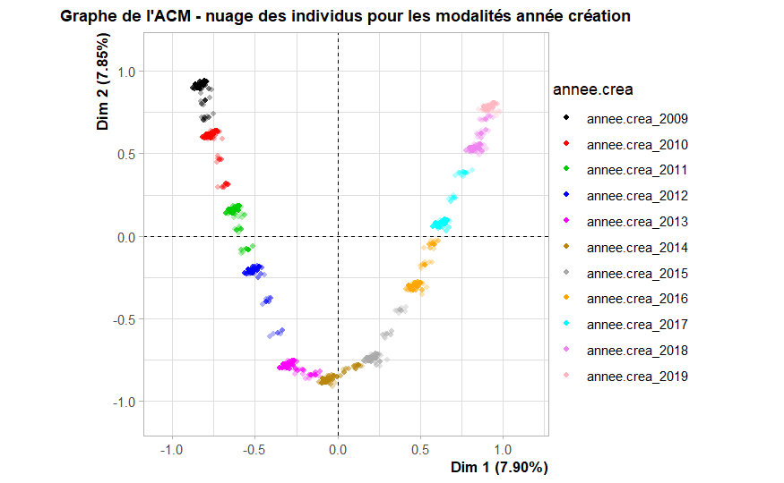

```r
# Nuage des individus pour les variables qualitatives différentiantes
plot.MCA(res.MCA,invisible= c("var","quali.sup","quanti.sup"),select="annee.crea",habillage = "annee.crea", title="Graphe de l'ACM - nuage des individus pour les modalités année création",label = c("none"))
```

### Essai numéro 3) Création d’une catégorie pour les dates prenant uniquement 3 valeurs suivant l’échelle : ancien (années 2009 à 2011), moyen (années 2012 à 2016) et récent (années 2017 à 2020)

```r
res.MCA <- MCA(datingDateEchelle, quanti.sup=c(1:6), graph=FALSE)
summary (res.MCA)
```

```
Call:
MCA(X = datingDateEchelle, quanti.sup = c(1:6), graph = FALSE)


Eigenvalues
                       Dim.1   Dim.2   Dim.3   Dim.4   Dim.5   Dim.6   Dim.7   Dim.8
Variance               0.372   0.368   0.160   0.127   0.124   0.123   0.117   0.098
% of var.             24.811  24.517  10.652   8.494   8.276   8.199   7.809   6.521
Cumulative % of var.  24.811  49.328  59.981  68.475  76.751  84.950  92.759  99.280
                       Dim.9  Dim.10  Dim.11  Dim.12
Variance               0.006   0.003   0.002   0.001
% of var.              0.375   0.169   0.120   0.055
Cumulative % of var.  99.655  99.824  99.945 100.000

Individuals (the 10 first)
                   Dim.1    ctr   cos2    Dim.2    ctr   cos2    Dim.3    ctr   cos2
1               | -0.846  0.064  0.568 |  0.553  0.028  0.242 |  0.200  0.008  0.032 |
2               |  0.834  0.062  0.376 |  0.588  0.031  0.187 |  0.750  0.117  0.304 |
3               |  0.834  0.062  0.376 |  0.588  0.031  0.187 |  0.750  0.117  0.304 |
4               |  0.034  0.000  0.001 | -0.665  0.040  0.352 |  0.271  0.015  0.058 |
5               |  0.001  0.000  0.000 | -0.673  0.041  0.390 | -0.337  0.024  0.098 |
6               |  0.819  0.060  0.527 |  0.588  0.031  0.271 |  0.218  0.010  0.037 |
7               | -0.839  0.063  0.316 |  0.537  0.026  0.129 |  0.369  0.028  0.061 |
8               |  0.811  0.059  0.395 |  0.571  0.030  0.196 | -0.145  0.004  0.013 |
9               |  0.819  0.060  0.527 |  0.588  0.031  0.271 |  0.218  0.010  0.037 |
10              | -0.008  0.000  0.000 | -0.667  0.040  0.406 |  0.306  0.020  0.085 |

Categories (the 10 first)
                    Dim.1     ctr    cos2  v.test     Dim.2     ctr    cos2  v.test
gender_0        |   0.019   0.006   0.000   1.046 |  -0.015   0.004   0.000  -0.801 |
gender_1        |  -0.027   0.012   0.001  -1.427 |   0.020   0.007   0.000   1.060 |
gender_2        |   0.179   0.021   0.001   1.378 |  -0.122   0.010   0.000  -0.940 |
voyage_0        |   0.019   0.009   0.001   1.938 |   0.010   0.003   0.000   1.000 |
voyage_1        |  -0.066   0.033   0.001  -1.938 |  -0.034   0.009   0.000  -1.000 |
laugh_0         |   0.017   0.008   0.001   1.895 |   0.008   0.002   0.000   0.850 |
laugh_1         |  -0.070   0.032   0.001  -1.895 |  -0.031   0.007   0.000  -0.850 |
photo.keke_0    |  -0.020   0.011   0.002  -2.473 |  -0.015   0.007   0.001  -1.895 |
photo.keke_1    |   0.103   0.058   0.002   2.473 |   0.079   0.034   0.001   1.895 |
photo.beach_0   |  -0.013   0.005   0.001  -1.559 |   0.000   0.000   0.000  -0.028 |
                  Dim.3     ctr    cos2  v.test
```

[output cut: 15 more lines]

```
laugh                       | 0.001 0.000 0.009 |
photo.keke                  | 0.002 0.001 0.283 |
photo.beach                 | 0.001 0.000 0.411 |
annee.crea.echelle          | 0.986 0.971 0.000 |
annee.last.connex.echelle   | 0.990 0.980 0.000 |
annee.last.up.photo.echelle | 0.994 0.989 0.000 |

Supplementary continuous variables
                   Dim.1    Dim.2    Dim.3
score           | -0.017 |  0.030 |  0.256 |
n.matches       | -0.015 |  0.022 | -0.018 |
n.updates.photo | -0.002 |  0.011 |  0.003 |
n.photos        | -0.002 |  0.004 |  0.237 |
sent.ana        |  0.010 |  0.011 | -0.039 |
length.prof     |  0.010 | -0.034 | -0.120 |
```

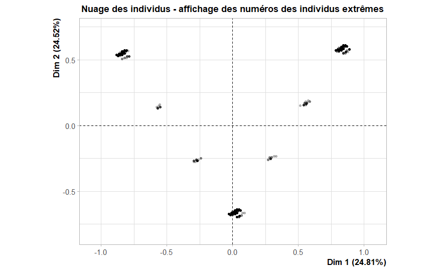

```r
# Nuage des individus
plot.MCA (res.MCA, invisible= c("var","quali.sup"), cex = 0.7, select = "coord 10", title = "Nuage des individus - affichage des numéros des individus extrêmes")
```

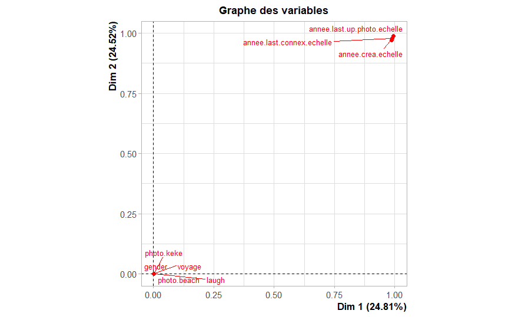

```r
# Graphe des variables
plot.MCA(res.MCA, choix='var',invisible=c('quali.sup','quanti.sup'),title="Graphe des variables", cex =0.7)
```

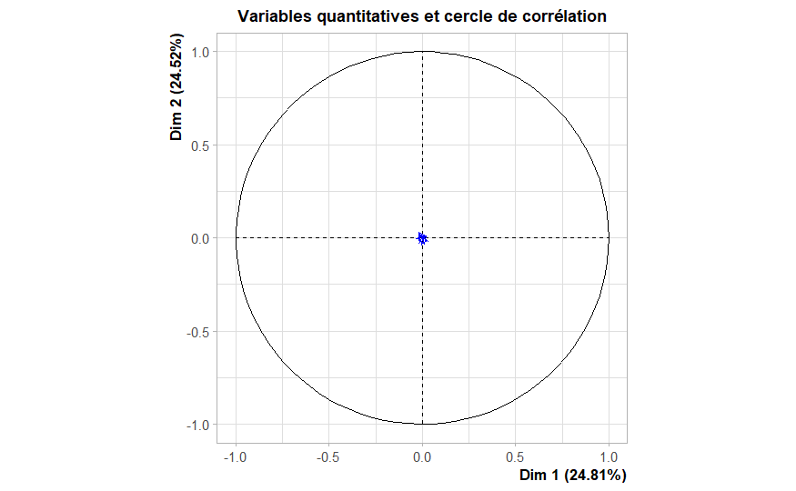

```r
# Variables quantitatives sur cercle de corrélation
plot.MCA (res.MCA, choix = "quanti.sup", title = "Variables quantitatives et cercle de corrélation")
```

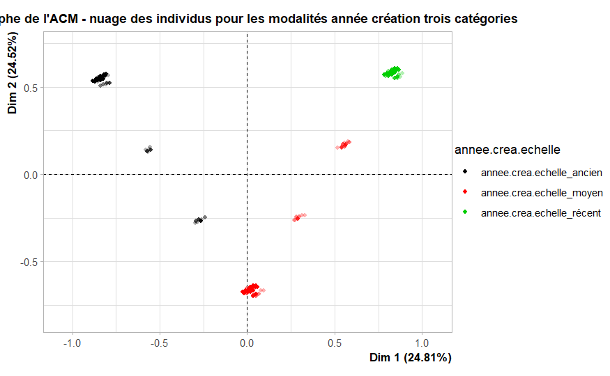

```r
# Nuage des individus pour les variables qualitatives différentiantes
plot.MCA(res.MCA,invisible= c("var","quali.sup","quanti.sup"),select="annee.crea.echelle",habillage = "annee.crea.echelle", title="Graphe de l'ACM - nuage des individus pour les modalités année création trois catégories",label = c("none"))
```

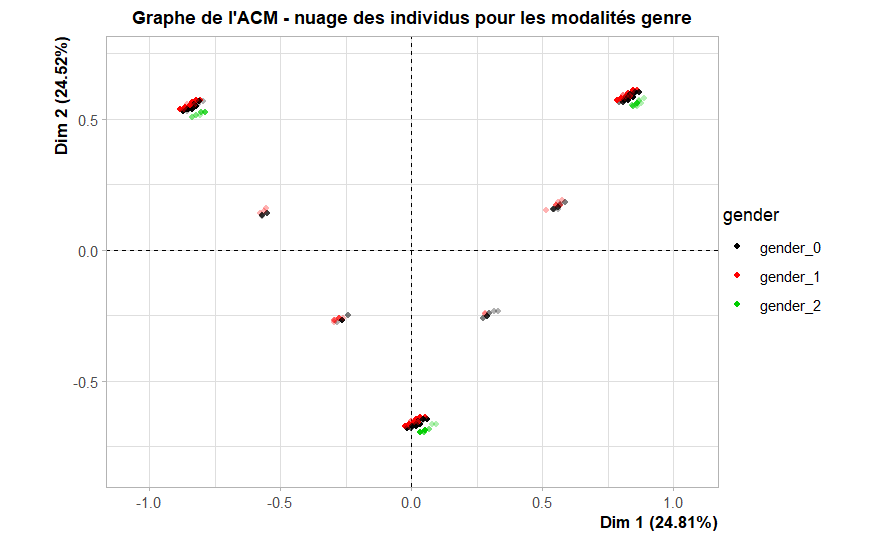

```r
plot.MCA(res.MCA,invisible= c("var","quali.sup","quanti.sup"),select="gender",habillage = "gender", title="Graphe de l'ACM - nuage des individus pour les modalités genre",label = c("none"))
```

### Essai numéro 4) ACM avec les années en variables qualitatives supplémentaires. Cette option est retenue pour la suite de l’analyse.

```r
res.MCA <- MCA(datingDA, quanti.sup=c(1,2,3,4,5,6), quali.sup=12:14, graph=FALSE)
summary (res.MCA)
```

```
Call:
MCA(X = datingDA, quanti.sup = c(1, 2, 3, 4, 5, 6), quali.sup = 12:14,
     graph = FALSE)


Eigenvalues
                       Dim.1   Dim.2   Dim.3   Dim.4   Dim.5   Dim.6
Variance               0.256   0.204   0.199   0.197   0.188   0.157
% of var.             21.308  17.001  16.569  16.399  15.673  13.051
Cumulative % of var.  21.308  38.309  54.878  71.277  86.949 100.000

Individuals (the 10 first)
                   Dim.1    ctr   cos2    Dim.2    ctr   cos2    Dim.3    ctr   cos2
1               |  0.261  0.009  0.169 | -0.348  0.020  0.300 |  0.097  0.002  0.023 |
2               |  0.932  0.113  0.654 | -0.365  0.022  0.100 | -0.054  0.000  0.002 |
3               |  0.932  0.113  0.654 | -0.365  0.022  0.100 | -0.054  0.000  0.002 |
4               |  0.344  0.015  0.091 | -0.302  0.015  0.070 |  0.094  0.001  0.007 |
5               | -0.421  0.023  0.153 |  0.329  0.018  0.093 | -0.419  0.029  0.152 |
6               |  0.261  0.009  0.169 | -0.348  0.020  0.300 |  0.097  0.002  0.023 |
7               |  0.475  0.029  0.116 |  0.370  0.022  0.070 | -0.070  0.001  0.003 |
8               | -0.196  0.005  0.037 |  0.387  0.024  0.145 |  0.080  0.001  0.006 |
9               |  0.261  0.009  0.169 | -0.348  0.020  0.300 |  0.097  0.002  0.023 |
10              |  0.392  0.020  0.147 |  0.324  0.017  0.100 | -0.068  0.001  0.004 |

Categories (the 10 first)
                    Dim.1     ctr    cos2  v.test     Dim.2     ctr    cos2  v.test
gender_0        |  -0.742  21.634   0.556 -40.839 |  -0.009   0.004   0.000  -0.489 |
gender_1        |   0.745  20.751   0.508  39.040 |  -0.151   1.063   0.021  -7.891 |
gender_2        |   0.867   1.137   0.015   6.667 |   3.954  29.630   0.308  30.402 |
voyage_0        |  -0.074   0.329   0.019  -7.543 |  -0.337   8.641   0.398 -34.534 |
voyage_1        |   0.258   1.155   0.019   7.543 |   1.182  30.342   0.398  34.534 |
laugh_0         |   0.046   0.135   0.009   5.152 |  -0.271   5.810   0.303 -30.140 |
laugh_1         |  -0.191   0.557   0.009  -5.152 |   1.116  23.885   0.303  30.140 |
photo.keke_0    |   0.233   3.575   0.285  29.237 |  -0.034   0.097   0.006  -4.303 |
photo.keke_1    |  -1.222  18.720   0.285 -29.237 |   0.180   0.508   0.006   4.303 |
photo.beach_0   |  -0.291   5.495   0.409 -35.032 |   0.006   0.003   0.000   0.778 |
                  Dim.3     ctr    cos2  v.test
gender_0          0.055   0.154   0.003   3.039 |
gender_1         -0.274   3.620   0.069 -14.379 |
gender_2          5.349  55.643   0.564  41.130 |
```

[output cut: 28 more lines]

```

Supplementary categorical variables (eta2)
                      Dim.1 Dim.2 Dim.3
annee.crea          | 0.002 0.005 0.006 |
annee.last.connex   | 0.003 0.003 0.006 |
annee.last.up.photo | 0.002 0.005 0.006 |

Supplementary continuous variables
                   Dim.1    Dim.2    Dim.3
score           |  0.256 | -0.149 |  0.066 |
n.matches       | -0.018 | -0.023 |  0.020 |
n.updates.photo |  0.003 | -0.004 |  0.014 |
n.photos        |  0.237 | -0.049 | -0.076 |
sent.ana        | -0.039 |  0.009 |  0.035 |
length.prof     | -0.120 | -0.021 |  0.005 |
```

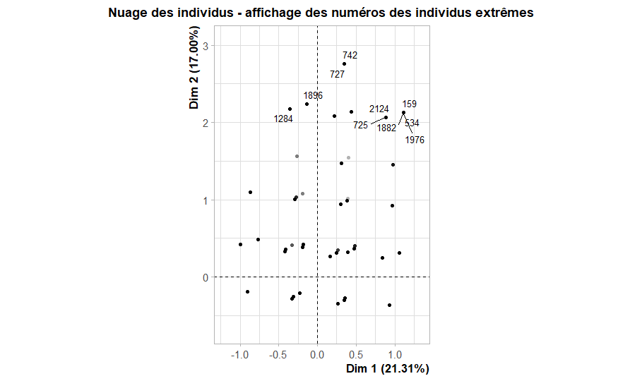

```r
# Nuage des individus
plot.MCA (res.MCA, invisible= c("var","quali.sup"), cex = 0.7, select = "coord 20", title = "Nuage des individus - affichage des numéros des individus extrêmes")
```

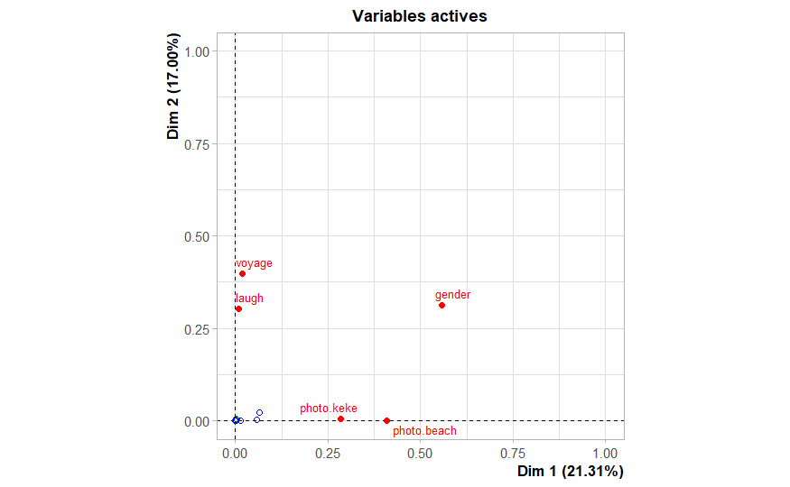

```r
# Graphe des variables

plot.MCA (res.MCA, choix = "var", cex=0.7, title = "Variables actives")
```

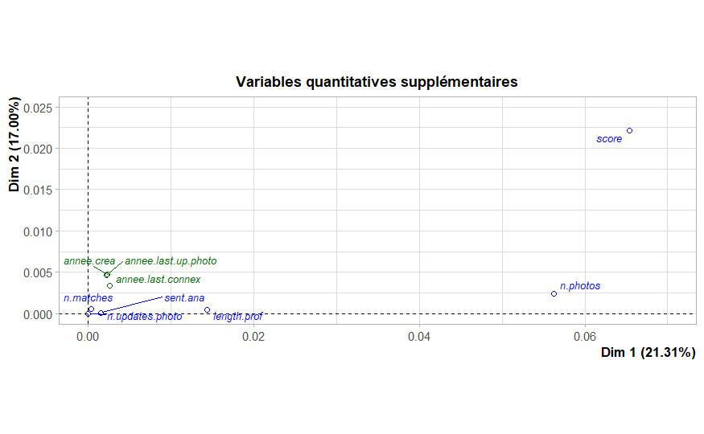

```r
plot.MCA (res.MCA, choix = "var", xlim=c(0,0.07), ylim=c(0,0.025), cex=0.7, invisible=c("var"), title="Variables quantitatives supplémentaires")
```

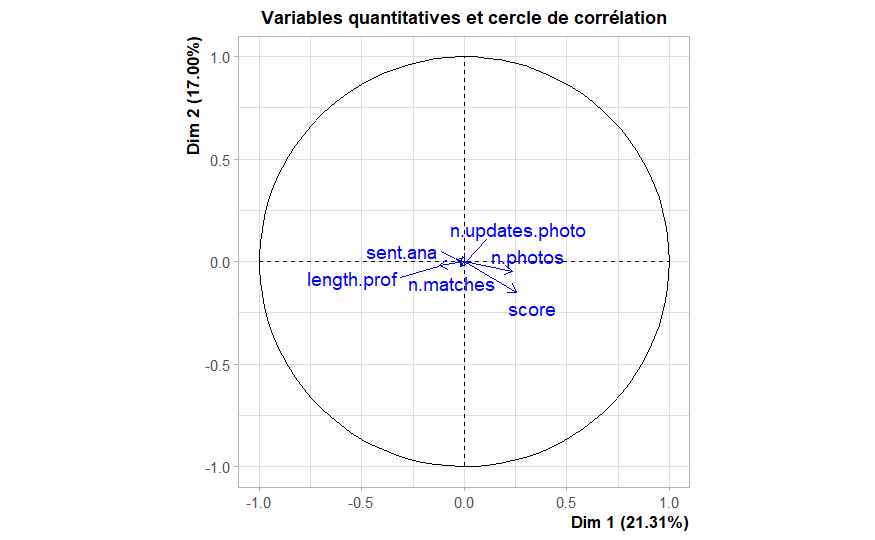

```r
# Variables quantitatives sur cercle de corrélation
plot.MCA (res.MCA, choix = "quanti.sup", title = "Variables quantitatives et cercle de corrélation")
```

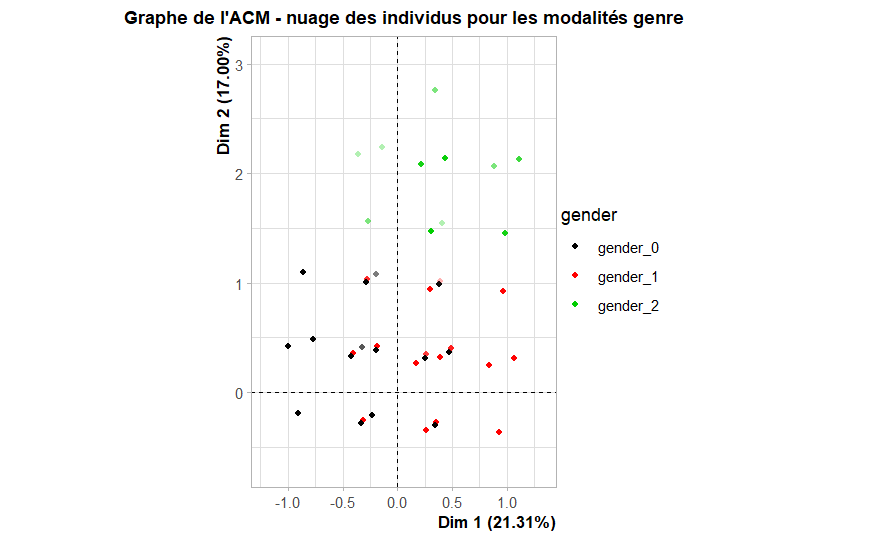

```r
# Nuage des individus pour les variables qualitatives différentiantes
plot.MCA(res.MCA,invisible= c("var","quali.sup","quanti.sup"),select="gender",habillage = "gender", title="Graphe de l'ACM - nuage des individus pour les modalités genre",label = c("none"))
```

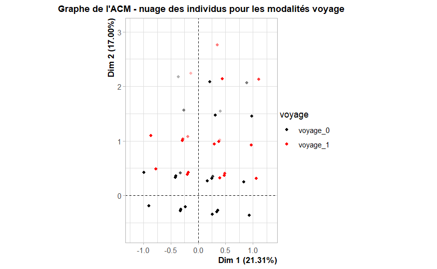

```r
plot.MCA(res.MCA,invisible= c("var","quali.sup","quanti.sup"),select="voyage",habillage = "voyage", title="Graphe de l'ACM - nuage des individus pour les modalités voyage",label = c("none"))
```

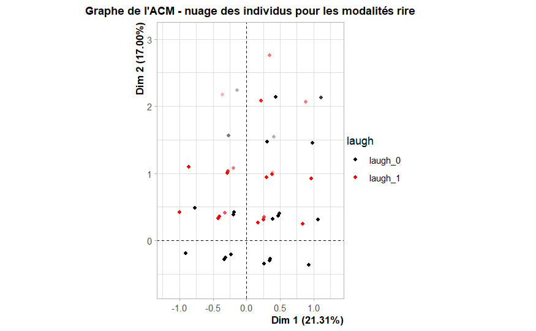

```r
plot.MCA(res.MCA,invisible= c("var","quali.sup","quanti.sup"),select="laugh",habillage = "laugh", title="Graphe de l'ACM - nuage des individus pour les modalités rire",label = c("none"))
```

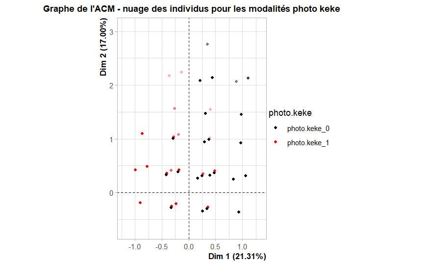

```r
plot.MCA(res.MCA,invisible= c("var","quali.sup","quanti.sup"),select="photo.keke",habillage = "photo.keke", title="Graphe de l'ACM - nuage des individus pour les modalités photo keke",label = c("none"))
```

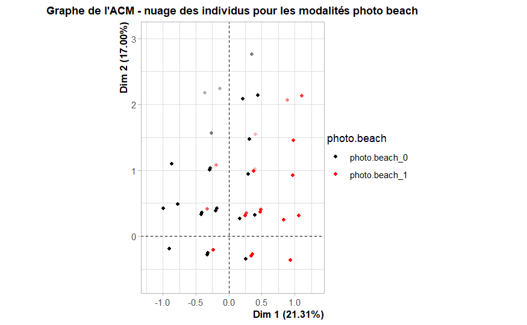

```r
plot.MCA(res.MCA,invisible= c("var","quali.sup","quanti.sup"),select="photo.beach",habillage = "photo.beach", title="Graphe de l'ACM - nuage des individus pour les modalités photo beach",label = c("none"))
```

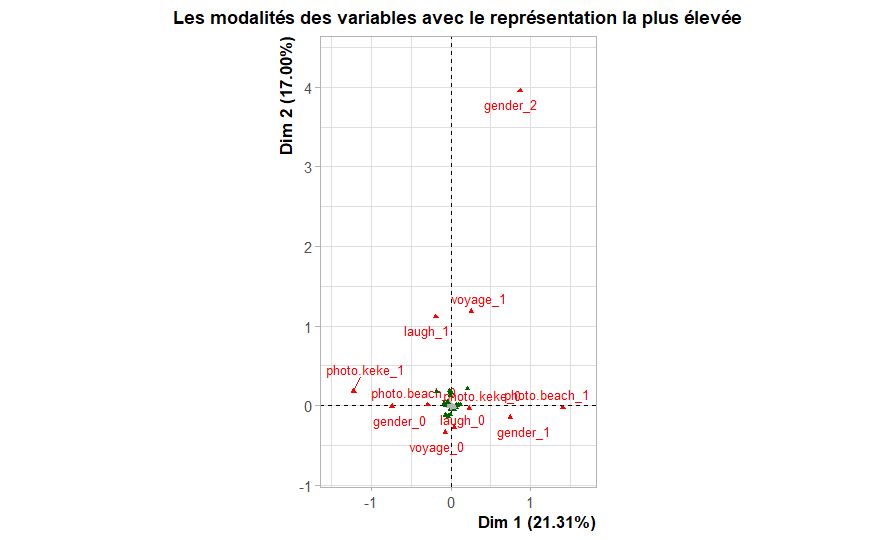

```r
# Représentation d'individus ou de modalités particuliers
plot.MCA (res.MCA, invisible= c("ind"), autoLab = "y", cex = 0.7, selectMod = "cos2 20", unselect = "grey70", title = "Les modalités des variables avec le représentation la plus élevée") # les modalités des variables actives et les 20 modalités des variables supplémentaires avec qualité de représentation la plus élevée
```

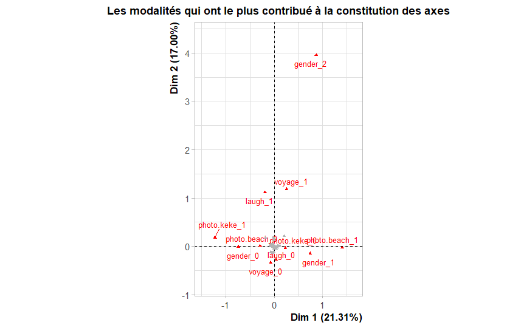

```r
plot.MCA (res.MCA, invisible= c("ind"), autoLab = "y", cex = 0.7, selectMod = "contrib 20", unselect = "grey70", title = "Les modalités qui ont le plus contribué à la constitution des axes") # les modalités des variables actives qui ont le plus contribué à la constitution des axes
```

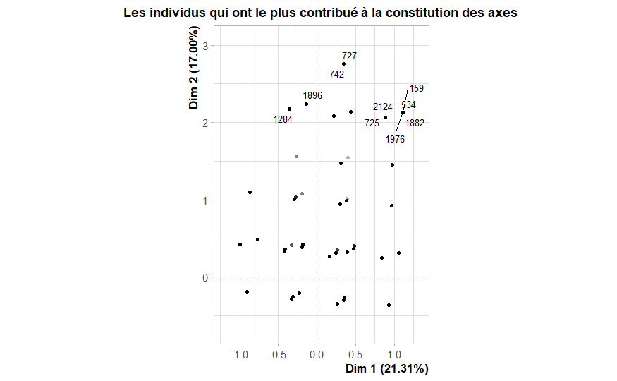

```r
plot.MCA (res.MCA, invisible= c("var","quali.sup"), autoLab = "y", cex = 0.7, select = "contrib 20", title = "Les individus qui ont le plus contribué à la constitution des axes") # les individus qui ont le plus contribué à la constitution des axes
```

Les individus semblent avoir des coordonnées identiques dans les nuages d’individus.Sans doute car ils sont nombreux et que l’echelle est petite.

## 3. Que constatez vous quant à la variance représentée sur ce plan ?

La variance est expliquée à 21,3% sur la dimension 1 et à 17% sur la dimension 2 dans l’option retenue. Dans le premier essai (date complète), la variance expliquée était très faible avec 0,059 sur la dimension 1 et de 0,056 sur la dimension 2.

## 4. Nonobstant la valeur de la variance associée aux deux premiers axes, tâchez de décrire sans valeur chiffrée ce que vous visualisez dans la dernière figure, en termes de phénomène macrosocial. Il s’agit ici de faire émerger des formes de profils-type d’utilisateurs d’application de dating

Le genre, la photo.beach et la photo.keke sont les variables les plus marquantes de la dimension 1. Tandis que le voyage, le genre et le rire sont les variables les plus marquantes de la dimension 2. Cela orienterait vers deux profils type : un profil d’utilisateurs qui postent des photos et un profil d’utilisateur qui parlent de voyage et aime le rire.

## 5. Représentez la saturation des variables sur les deux premiers axes via une table

```r
sweep(res.MCA$var$coord,2,sqrt(res.MCA$eig[1:ncol(res.MCA$var$coord),1]),FUN="/")
```

```
                    Dim 1       Dim 2      Dim 3       Dim 4       Dim 5
gender_0      -1.46693940 -0.01965404  0.1237901 -0.05942213 -0.14199349
gender_1       1.47329055 -0.33339181 -0.6153723 -0.11685021  0.04340397
gender_2       1.71458563  8.75383028 11.9960047  4.43399609  2.61870497
voyage_0      -0.14536405 -0.74506220  0.1824937  0.87576145  0.19193358
voyage_1       0.51041363  2.61612067 -0.6407860 -3.07504209 -0.67393221
laugh_0        0.09176338 -0.60098925  0.6490712 -0.64744573  0.07846785
laugh_1       -0.37721470  2.47050607 -2.6681583  2.66147625 -0.32256035
photo.keke_0   0.46136203 -0.07601533  0.1381989  0.18801444 -0.75290086
photo.keke_1  -2.41615582  0.39809274 -0.7237487 -0.98463282  3.94294648
photo.beach_0 -0.57590960  0.01432500  0.1290464 -0.04622197 -0.59930673
photo.beach_1  2.77890362 -0.06912163 -0.6226804  0.22303224  2.89180043
```

# 5 Projet 4 : Classification non supervisée par DBSCAN

## 0. Préparation des données

```r
#lecture du fichier jeu de données Data Analyst
demilunesDA <- read.table("C:/Users/vgdb/Documents/DUDA/demi-lunes.csv", header=TRUE, sep = ",", dec = ".", fileEncoding = "latin1", check.names = FALSE, row.names = 1)
demilunesDA
```

|  | Y |
| --- | --- |
| -0.650724780975663 | 0.935256873 |
| 1.57346133437545 | 0.014193964 |
| 1.67239768070015 | -0.236687166 |
| 0.711085863019255 | 0.942112789 |
| -1.07133936937374 | 0.339345892 |
| 0.796618483580165 | 0.250878678 |
| 1.27186251835043 | -0.616336080 |
| -0.782752486152006 | 0.435012180 |
| -0.851984643525623 | 0.613675765 |
| 1.41799419466836 | -0.280065981 |

[output cut: 990 more lines]

## 1. Produisez un jeu de données aléatoires en forme de lunes se faisant face. Utiliser le jeu de données fourni par l’enseignant si vous utilisez R

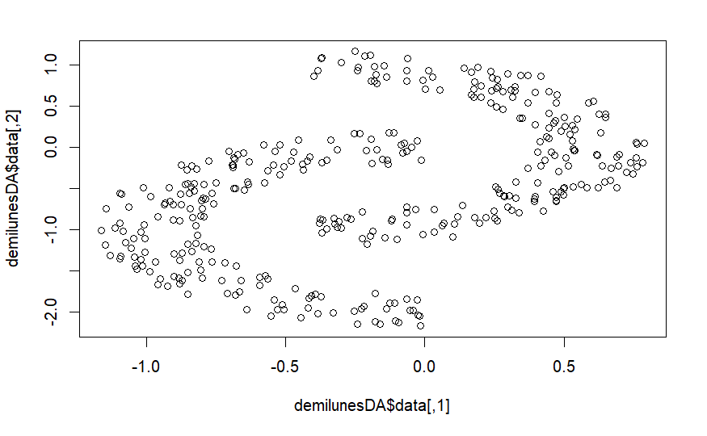

```r
#install.packages("clusterSim")
library(clusterSim)
demilunesDA<-shapes.two.moon(180)
plot(demilunesDA$data)
```

## 2. Utilisez les trois techniques de clustering kmeans, CAH et DBSCAN. Reproduisez les graphiques correspondants.

Clustering avec kmeans

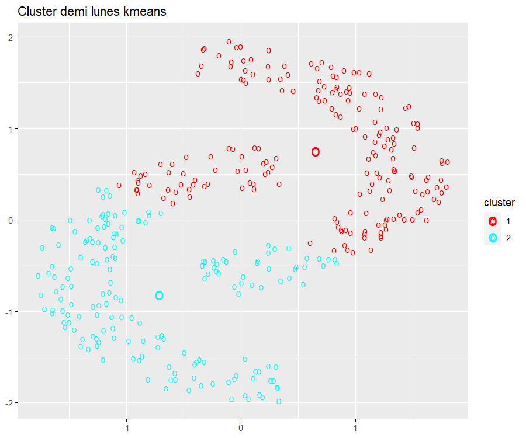

```r
#cluster par kmeans
#res.pcacr$ind$coord[,1:2]
res.kmdemilunes <- kmeans(demilunesDA$data, centers = 2, nstart = 20)
#res.kmpc12 <- kmeans(res.pca$ind$coord[,1:2], centers = 3, nstart = 20)

#res.kmdemilunes
#demilunesDA

fviz_cluster(res.kmdemilunes, data = as.data.frame(demilunesDA$data[,1:2]), shape = "o",pointsize = 3,
             palette = rainbow(2),
             geom = c("point"),
             ellipse = FALSE,
             xlab = FALSE,
             ylab = FALSE,
             #ggtheme = theme_bw(),
             main = "Cluster demi lunes kmeans"
             #xlab = "", ylab = "", yaxt='n', xaxt='n'
             )
```

Clustering avec CAH

```r
#cluster par CAH method = ward.D2
datacah <- demilunesDA$data
dist_mat <- dist(datacah)
hclust.out <- hclust(d = dist_mat, method="ward.D2")
#cut.cah
#summary (hcust.out)
```

```r
cut.cah <- cutree(hclust.out, k=2)
#cut.cah
```

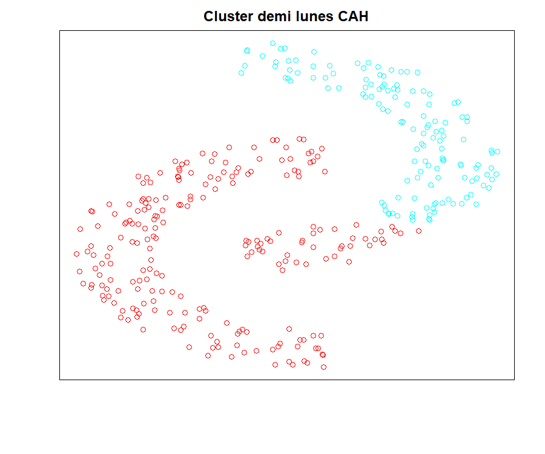

```r
library(ggrepel)
plotdata <- data.frame(cbind(datacah, cut.cah))

plot(datacah,col=rainbow(2)[cut.cah], main = "Cluster demi lunes CAH", xlab = "", ylab = "",yaxt='n', xaxt='n')
```

Clustering avec DBSCAN

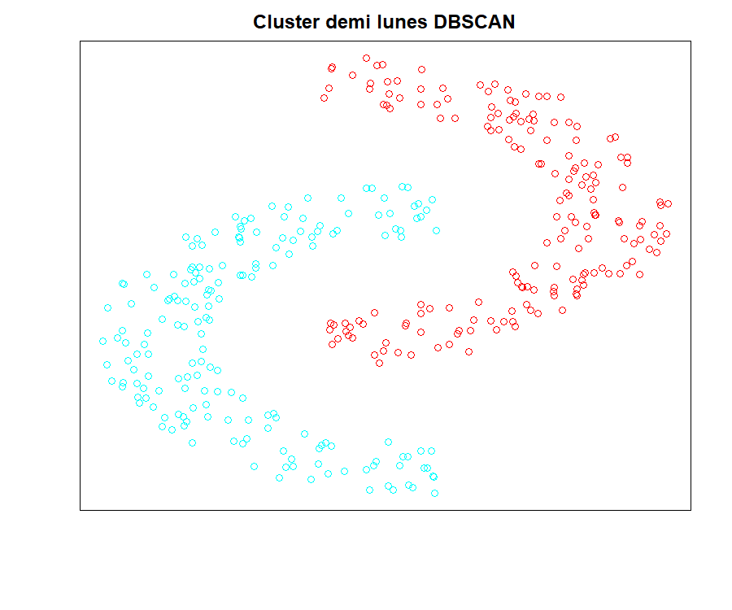

```r
# Installing Packages
#install.packages("fpc")

# Loading package
library(fpc)

# application de dbscan pour répartir les points en cluster distance = 0.25 et nombre de points voisins = 5
Dbscan_demilunesDA <- dbscan(demilunesDA$data, eps = 0.25, MinPts = 5)
#Dbscan_demilunesDA

# Vérification
#data.frame(Dbscan_demilunesDA$cluster)
#data.frame(demilunesDA$data)

# DF cluster
demilunes_cluster <- cbind(Dbscan_demilunesDA$cluster, demilunesDA$data)
#data.frame (demilunes_cluster)

# Plot
plot(demilunes_cluster[,2:3],col=rainbow(2)[demilunes_cluster[,1]], main = "Cluster demi lunes DBSCAN", xlab = "", ylab = "", yaxt='n', xaxt='n')
```

On remarque que seule la méthode de cluster DBSCAN permet de séparer les deux demi-lunes.